# Analisi serie storica MNM38

### Fabio Palmigiani

Il documento illustra l’analisi della serie storica MNM38, estrapolata dal file “MC1001” che contiene 1001 time series usate per una nota gara di forecast patrocinata dall’IIF. (https://forecasters.org/resources/time-series-data/m-competition/).

Per facilitarne la lettura la serie interessata, è stata estrapolata dal file “MC1001” e inserita in un nuovo file excel chiamato “MNM38”.

Le librerie usate sono state omesse da questo documento in modo da renderlo più snello. (esse sono comunque visibili sul codice MNM38.R)

## Analisi preliminare

La prima cosa che è stata fatta, dopo ovviamente aver imortato il dataset, è “aggiustare” quest’ultimo, sono state infatti aggiunte le colonne mese e anno, una colonna “t” come contatore di tempo ed è stata rinominata la colonna dei valori. Successivamente è stato diviso il dataset in trainig set e test set, si è deciso di utilizzare l’85% dei dati come training e il restante come test.

```r
################### DATA PREPARATION ###################

MNM38 <- t(read_excel("MNM38.xlsx"))
MNM38_vec = vec(MNM38)

# Aggiungo la colonne anno e mese nel data set
MNM38_ts <- ts(MNM38_vec, start=c(1977, 12), frequency=12)
MNM38_df <- data.frame(Year = trunc(time(MNM38_ts)), Month=month.abb[cycle(MNM38_ts)], MNM38_ts)
head(MNM38_df)
```

```
##   Year Month Series.1
## 1 1977   Dec     8458
## 2 1978   Jan     7323
## 3 1978   Feb     7796
## 4 1978   Mar     7339
## 5 1978   Apr     6650
## 6 1978   May     9032
```

```r
# Aggiungo la colonna t
MNM38_df <- add_column(MNM38_df, t=c(1:nrow(MNM38_df)), .before="Year")
head(MNM38_df)
```

```
##   t Year Month Series.1
## 1 1 1977   Dec     8458
## 2 2 1978   Jan     7323
## 3 3 1978   Feb     7796
## 4 4 1978   Mar     7339
## 5 5 1978   Apr     6650
## 6 6 1978   May     9032
```

```r
# Rinomino la colonna Series.1 in Values
MNM38_df <- MNM38_df %>% rename("Series.1" = "Values")
head(MNM38_df)
```

```
##   t Year Month Values
## 1 1 1977   Dec   8458
## 2 2 1978   Jan   7323
## 3 3 1978   Feb   7796
## 4 4 1978   Mar   7339
## 5 5 1978   Apr   6650
## 6 6 1978   May   9032
```

```r
# Utilizzo l'85% dei dati come training set
Data_df <- MNM38_df
length <- nrow(Data_df)
TS_length <- floor(length*0.85)
TsS_length <- length - TS_length
```

in modo tale da averne una prima rappresentazione visiva, sono stati disegnati lo scatter plot ed il line plot della serie.

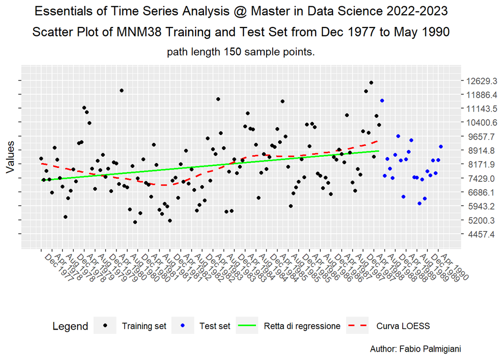

```r
# Scatter plot
First_Date <- paste(Data_df$Month[1],Data_df$Year[1])
Last_Date <- paste(Data_df$Month[length],Data_df$Year[length])
title_content <- bquote(atop("Essentials of Time Series Analysis \u0040 Master in Data Science 2022-2023",
                             paste("Scatter Plot of MNM38 Training and Test Set from ", .(First_Date), " to ", .(Last_Date))))
subtitle_content <- bquote(paste("path length ", .(length), " sample points."))
caption_content <- "Author: Fabio Palmigiani"
x_name <- bquote("")
x_breaks_num <- 30
x_breaks_low <- Data_df$t[1]
x_breaks_up <- Data_df$t[length]
x_binwidth <- floor((x_breaks_up-x_breaks_low)/x_breaks_num)
x_breaks <- seq(from=x_breaks_low, to=x_breaks_up, by=x_binwidth)
if((max(x_breaks)-x_breaks_up)>x_binwidth/2){x_breaks <- c(x_breaks,x_breaks_up)}
x_labs <- paste(Data_df$Month[x_breaks],Data_df$Year[x_breaks])
J <- 0
x_lims <- c(x_breaks_low-J*x_binwidth, x_breaks_up+J*x_binwidth)
y_name <- bquote("Values")
y_breaks_num <- 10
y_max <- max(na.omit(Data_df$Values))
y_min <- min(na.omit(Data_df$Values))
y_binwidth <- round((y_max-y_min)/y_breaks_num, digits=3)
y_breaks_low <- floor((y_min/y_binwidth))*y_binwidth
y_breaks_up <- ceiling((y_max/y_binwidth))*y_binwidth
y_breaks <- round(seq(from=y_breaks_low, to=y_breaks_up, by=y_binwidth),3)
y_labs <- format(y_breaks, scientific=FALSE)
K <- 0.5
y_lims <- c((y_breaks_low-K*y_binwidth), (y_breaks_up+K*y_binwidth))
col_k <- bquote("Training set")
col_b <- bquote("Test set")
col_g <- bquote("Retta di regressione")
col_r <- bquote(" Curva LOESS")
leg_labs   <- c(col_k, col_b, col_g, col_r)
leg_cols   <- c("col_k"="black", "col_b"="blue", "col_r"="red", "col_g"="green")
leg_breaks <- c("col_k", "col_b", "col_g", "col_r")
MNM38_sp <- ggplot(Data_df) +
  geom_smooth(data=subset(Data_df, Data_df$t <= t[TS_length]), alpha=1, size = 0.8, linetype="solid",
              aes(x=t, y=Values, color="col_g"),
              method = "lm" , formula = y ~ x, se=FALSE, fullrange=FALSE) +
  geom_smooth(data=subset(Data_df, Data_df$t <= t[TS_length]), alpha=1, size = 0.8, linetype="dashed",
              aes(x=t, y=Values, color="col_r"), method = "loess", formula = y ~ x, se=FALSE) +
  geom_point(data=subset(Data_df, Data_df$t <= t[TS_length]), alpha=1, size=1.5, shape=19,
             aes(x=t, y=Values, color="col_k")) +
  geom_point(data=subset(Data_df, Data_df$t > t[TS_length]), alpha=1, size=1.5, shape=19,
             aes(x=t, y=Values, color="col_b")) +
  scale_x_continuous(name=x_name, breaks=x_breaks, label=x_labs, limits=x_lims) +
  scale_y_continuous(name=y_name, breaks=y_breaks, labels=NULL, limits=y_lims,
                     sec.axis = sec_axis(~., breaks=y_breaks, labels=y_labs)) +
  ggtitle(title_content) +
  labs(subtitle=subtitle_content, caption=caption_content) +
  scale_colour_manual(name="Legend", labels=leg_labs, values=leg_cols, breaks=leg_breaks,
                      guide=guide_legend(override.aes=list(shape=c(19,19,NA,NA),
                                                           linetype=c("blank", "blank", "solid", "dashed")))) +
  theme(plot.title=element_text(hjust=0.5),
        plot.subtitle=element_text(hjust= 0.5),
        axis.text.x = element_text(angle=-45, vjust=1, hjust=-0.3),
        legend.key.width = unit(0.8,"cm"), legend.position="bottom")
plot(MNM38_sp)
```

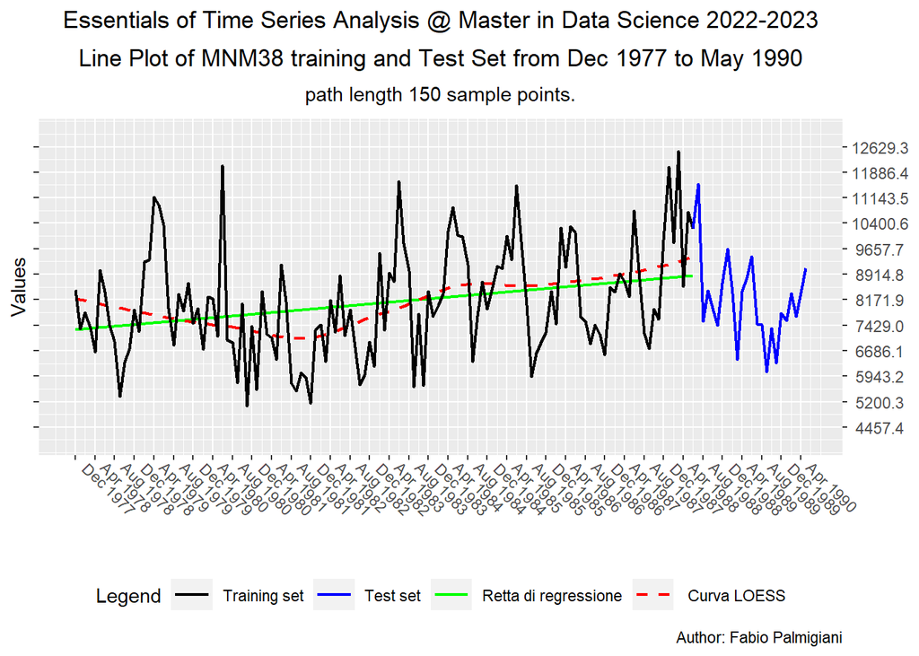

```r
# Line plot
title_content <- bquote(atop("Essentials of Time Series Analysis \u0040 Master in Data Science 2022-2023",
                             paste("Line Plot of MNM38 training and Test Set from ", .(First_Date), " to ", .(Last_Date))))
MNM38_lp <- ggplot(Data_df) +
  geom_smooth(data=subset(Data_df, Data_df$t <= t[TS_length]), alpha=1, size = 0.8, linetype="solid",
              aes(x=t, y=Values, color="col_g"), method = "lm" , formula = y ~ x, se=FALSE,
              fullrange=FALSE) +
  geom_smooth(data=subset(Data_df, Data_df$t <= t[TS_length]), alpha=1, size = 0.8, linetype="dashed",
              aes(x=t, y=Values, color="col_r"), method = "loess", formula = y ~ x, se=FALSE) +
  geom_line(data=subset(Data_df, Data_df$t <= t[TS_length]), alpha=1, size=0.8, linetype="solid",
            aes(x=t, y=Values, color="col_k", group=1)) +
  geom_line(data=subset(Data_df, Data_df$t >= t[TS_length]), alpha=1, size=0.8, linetype="solid",
            aes(x=t, y=Values, color="col_b", group=1)) +
  scale_x_continuous(name=x_name, breaks=x_breaks, label=x_labs, limits=x_lims) +
  scale_y_continuous(name=y_name, breaks=y_breaks, labels=NULL, limits=y_lims,
                     sec.axis = sec_axis(~., breaks=y_breaks, labels=y_labs)) +
  ggtitle(title_content) +
  labs(subtitle=subtitle_content, caption=caption_content) +
  scale_colour_manual(name="Legend", labels=leg_labs, values=leg_cols, breaks=leg_breaks,
                      guide=guide_legend(override.aes=list(linetype=c("solid", "solid", "solid", "dashed")))) +
  theme(plot.title=element_text(hjust=0.5),
        plot.subtitle=element_text(hjust=0.5),
        axis.text.x = element_text(angle=-45, vjust=1, hjust=-0.3),
        legend.key.width = unit(0.8,"cm"), legend.position="bottom")
plot(MNM38_lp)
```

Da una prima analisi visiva, sembrerebbe esserci presenza di stagionalità, mentre non salta subito all’occhio la presenza di un forte trend, neppure di eteroschedasticità, ma per approfondire questi temi si è deciso di procedere con un’analisi più approfondita.

### Descrizione del modello tramite funzione lineare

Si è deciso di provare a descrivere il modello tramite una funzione lineare e, per valitarne la bontà ne si studiano i residui.

```r
# Funzione lineare
MNM38_lm <- lm(Values[1:TS_length]~t[1:TS_length], data=MNM38_df)
class(MNM38_lm)
```

```
## [1] "lm"
```

```r
MNM38_fit <- MNM38_lm[["fitted.values"]]
head(MNM38_fit)
```

```
##        1        2        3        4        5        6
## 7306.746 7319.208 7331.670 7344.132 7356.594 7369.056
```

```r
# prendo i residui
MNM38_res <- MNM38_lm[["residuals"]]
head(MNM38_res)
```

```
##           1           2           3           4           5           6
## 1151.254183    3.792206  464.330228   -5.131749 -706.593727 1662.944296
```

```r
# gradi di libertà dei residui
MNM38_degfr <- MNM38_lm[["df.residual"]]
show(MNM38_degfr)
```

```
## [1] 125
```

```r
# inserisco i dati derivanti dal modello lineare nel data frame
MNM38_lm_fitted <- c(as.vector(MNM38_fit), rep(NA, (length-TS_length)))
MNM38_lm_residuals <- c(as.vector(MNM38_res), rep(NA, (length-TS_length)))
MNM38_df <- add_column(MNM38_df, MNM38_lm_fit=MNM38_lm_fitted, MNM38_lm_res=MNM38_lm_residuals, .after="Values")
head(MNM38_df)
```

```
##   t Year Month Values MNM38_lm_fit MNM38_lm_res
## 1 1 1977   Dec   8458     7306.746  1151.254183
## 2 2 1978   Jan   7323     7319.208     3.792206
## 3 3 1978   Feb   7796     7331.670   464.330228
## 4 4 1978   Mar   7339     7344.132    -5.131749
## 5 5 1978   Apr   6650     7356.594  -706.593727
## 6 6 1978   May   9032     7369.056  1662.944296
```

```r
# creo una variabile che contiene solo i dati di test
MNM38_train_df <- MNM38_df[1:TS_length,]
head(MNM38_train_df)
```

```
##   t Year Month Values MNM38_lm_fit MNM38_lm_res
## 1 1 1977   Dec   8458     7306.746  1151.254183
## 2 2 1978   Jan   7323     7319.208     3.792206
## 3 3 1978   Feb   7796     7331.670   464.330228
## 4 4 1978   Mar   7339     7344.132    -5.131749
## 5 5 1978   Apr   6650     7356.594  -706.593727
## 6 6 1978   May   9032     7369.056  1662.944296
```

Si genera ora lo scatter plot ed il line plot dei residui della funzione lineare.

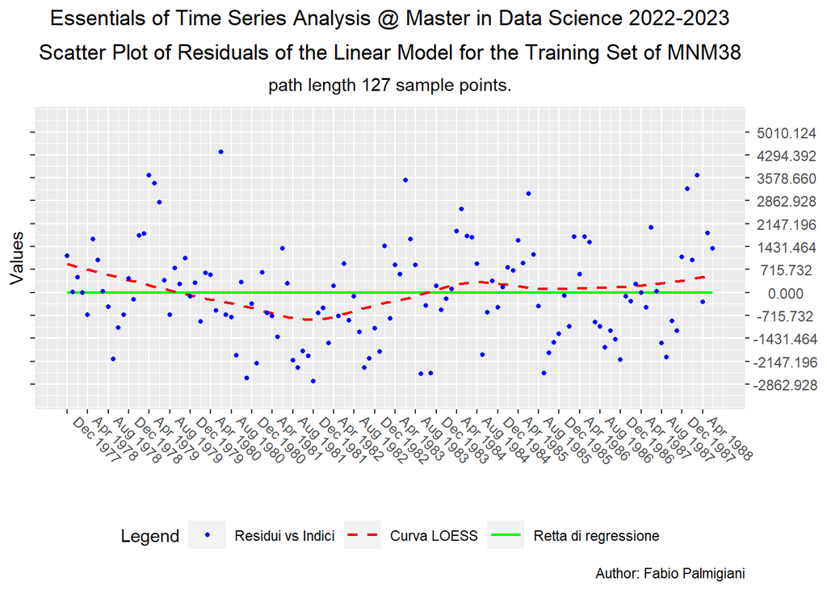

```r
# Scatter plot dei residui
Data_df  <- MNM38_train_df
length <- nrow(Data_df)
First_Date <- paste(Data_df$Month[1],Data_df$Year[1])
Last_Date <- paste(Data_df$Month[length],Data_df$Year[length])
title_content <- bquote(atop("Essentials of Time Series Analysis \u0040 Master in Data Science 2022-2023",
                             paste("Scatter Plot of Residuals of the Linear Model for the Training Set of MNM38")))
subtitle_content <- bquote(paste("path length ", .(length), " sample points."))
caption_content <- "Author: Fabio Palmigiani"
x_name <- bquote("")
y_name <- bquote("Values")
x_breaks_num <- 30
x_breaks_low <- Data_df$t[1]
x_breaks_up <- Data_df$t[length]
x_binwidth <- floor((x_breaks_up-x_breaks_low)/x_breaks_num)
x_breaks <- seq(from=x_breaks_low, to=x_breaks_up, by=x_binwidth)
if((max(x_breaks)-x_breaks_up)>x_binwidth/2){x_breaks <- c(x_breaks,x_breaks_up)}
x_labs <- paste(Data_df$Month[x_breaks],Data_df$Year[x_breaks])
J <- 0
x_lims <- c(x_breaks_low-J*x_binwidth, x_breaks_up+J*x_binwidth)
y_breaks_num <- 10
y_binwidth <- round((max(Data_df$MNM38_lm_res)-min(Data_df$MNM38_lm_res))/y_breaks_num, digits=3)
y_breaks_low <- floor((min(Data_df$MNM38_lm_res)/y_binwidth))*y_binwidth
y_breaks_up <- ceiling((max(Data_df$MNM38_lm_res)/y_binwidth))*y_binwidth
y_breaks <- round(seq(from=y_breaks_low, to=y_breaks_up, by=y_binwidth),3)
y_labs <- format(y_breaks, scientific=FALSE)
K <- 0.5
y_lims <- c((y_breaks_low-K*y_binwidth), (y_breaks_up+K*y_binwidth))
col_1 <- bquote("Residui vs Indici")
col_2 <- bquote("Curva LOESS")
col_3 <- bquote("Retta di regressione")
leg_labs <- c(col_1, col_2, col_3)
leg_cols <- c("col_1"="blue", "col_2"="red", "col_3"="green")
leg_breaks <- c("col_1", "col_2", "col_3")
MNM38_Res_sp <- ggplot(Data_df) +
  geom_smooth(alpha=1, size = 0.8, linetype="solid", aes(x=t, y=MNM38_lm_res, color="col_3"),
              method = "lm" , formula = y ~ x, se=FALSE, fullrange=TRUE) +
  geom_smooth(alpha=1, size = 0.8, linetype="dashed", aes(x=t, y=MNM38_lm_res, color="col_2"),
              method = "loess", formula = y ~ x, se=FALSE) +
  geom_point(alpha=1, size=1.0, shape=19, aes(x=t, y=MNM38_lm_res, color="col_1")) +
  scale_x_continuous(name=x_name, breaks=x_breaks, label=x_labs, limits=x_lims) +
  scale_y_continuous(name=y_name, breaks=y_breaks, labels=NULL, limits=y_lims,
                     sec.axis = sec_axis(~., breaks=y_breaks, labels=y_labs)) +
  ggtitle(title_content) +
  labs(subtitle=subtitle_content, caption=caption_content) +
  scale_colour_manual(name="Legend", labels=leg_labs, values=leg_cols, breaks=leg_breaks,
                      guide=guide_legend(override.aes=list(shape=c(19,NA,NA),
                                                           linetype=c("blank", "dashed", "solid")))) +
  theme(plot.title=element_text(hjust=0.5), plot.subtitle=element_text(hjust=0.5),
        axis.text.x = element_text(angle=-45, vjust=1, hjust=-0.3),
        legend.key.width = unit(0.8,"cm"), legend.position="bottom")
plot(MNM38_Res_sp)
```

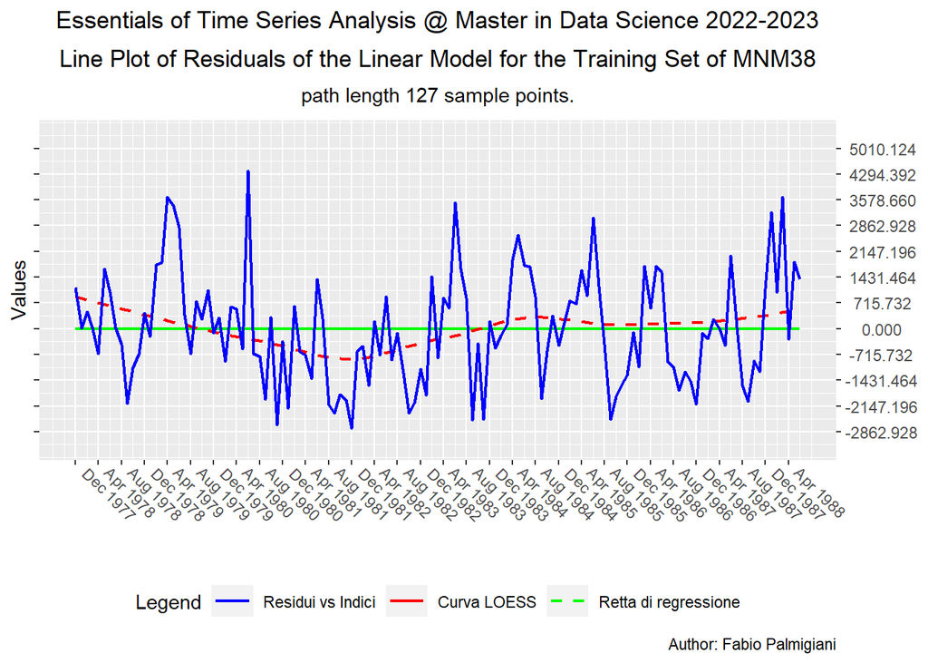

```r
# Line plot dei residui
Data_df  <- MNM38_train_df
title_content <- bquote(atop("Essentials of Time Series Analysis \u0040 Master in Data Science 2022-2023",
                             paste("Line Plot of Residuals of the Linear Model for the Training Set of MNM38")))
MNM38_Res_lp <- ggplot(Data_df) +
  geom_smooth(alpha=1, size = 0.8, linetype="solid", aes(x=t, y=MNM38_lm_res, color="col_3"),
              method = "lm" , formula = y ~ x, se=FALSE, fullrange=TRUE) +
  geom_smooth(alpha=1, size = 0.8, linetype="dashed", aes(x=t, y=MNM38_lm_res, color="col_2"),
              method = "loess", formula = y ~ x, se=FALSE) +
  geom_line(alpha=1, size=0.8, linetype="solid", aes(x=t, y=MNM38_lm_res, color="col_1")) +
  scale_x_continuous(name=x_name, breaks=x_breaks, label=x_labs, limits=x_lims) +
  scale_y_continuous(name=y_name, breaks=y_breaks, labels=NULL, limits=y_lims,
                     sec.axis = sec_axis(~., breaks=y_breaks, labels=y_labs)) +
  ggtitle(title_content) +
  labs(subtitle=subtitle_content, caption=caption_content) +
  scale_colour_manual(name="Legend", labels=leg_labs, values=leg_cols, breaks=leg_breaks,
                      guide=guide_legend(override.aes=list(linetype=c("solid", "solid", "dashed")))) +
  theme(plot.title=element_text(hjust=0.5), plot.subtitle=element_text(hjust=0.5),
        axis.text.x = element_text(angle=-45, vjust=1, hjust=-0.3),
        legend.key.width = unit(0.8,"cm"), legend.position="bottom")
plot(MNM38_Res_lp)
```

La prima cosa che è saltata all’occhio è la presenza di stagionalità, olte ad una curva LOESS quasi piatta che è una forte evidenza visiva della stazionarietà della media dei residui. Tuttavia, per verificare computazionalmente la stazionarietà di quest’ultimi si ricorre solitamente a un paio di test: il test Augmented Dickey-Fuller (ADF) e il test Kwiatowski-Phillips-Schmidt-Shin (KPSS). Il test ADF assume l’ipotesi nulla di non stazionarietà. Più precisamente, il test ADF assume che la serie temporale sia generata da un processo stocastico con una componente random walk. Questa ipotesi nulla porta a definire il test ADF come un test di radice unitaria. Al contrario, il test KPSS assume l’ipotesi nulla di stazionarietà. In definitiva, il test KPSS ipotizza che la serie temporale sia generata da un processo autoregressivo. Quindi, quando il test ADF rifiuta l’ipotesi nulla e il KPSS no, abbiamo la prova della stazionarietà della serie temporale. Quando invece il test ADF non rifiuta l’ipotesi nullo e il KPSS sì, abbiamo evidenza di non stazionarietà. Gli altri casi sono considerati dubbi.

Si è iniziato con l’eseguire il test di Augmented Dickey-Fuller (ADF):

```r
# ADF Test
MNM38_lm_res_ADF_none <- ur.df(MNM38_res, type="none", lags=0, selectlags="Fixed")
summary(MNM38_lm_res_ADF_none)
```

```
##
## ###############################################
## # Augmented Dickey-Fuller Test Unit Root Test #
## ###############################################
##
## Test regression none
##
##
## Call:
## lm(formula = z.diff ~ z.lag.1 - 1)
##
## Residuals:
##     Min      1Q  Median      3Q     Max
## -2907.8  -897.8  -188.6   810.2  4637.1
##
## Coefficients:
##         Estimate Std. Error t value Pr(>|t|)
## z.lag.1 -0.57099    0.08089  -7.059 1.02e-10 ***
## ---
## Signif. codes:  0 '***' 0.001 '**' 0.01 '*' 0.05 '.' 0.1 ' ' 1
##
## Residual standard error: 1388 on 125 degrees of freedom
## Multiple R-squared:  0.285,  Adjusted R-squared:  0.2793
## F-statistic: 49.83 on 1 and 125 DF,  p-value: 1.024e-10
##
##
## Value of test-statistic is: -7.059
##
## Critical values for test statistics:
##       1pct  5pct 10pct
## tau1 -2.58 -1.95 -1.62
```

Si è potuto quindi rifiutare l’ipoteri nulla in quanto il valore restituito è più piccolo del valore di riferimento del 1%.

Si è passato ad eseguire il test KPSS:

```r
# KPSS Test
MNM38_lm_res_KPSS_mu <- ur.kpss(MNM38_res, type="mu", lags="nil", use.lag=NULL)
summary(MNM38_lm_res_KPSS_mu)
```

```
##
## #######################
## # KPSS Unit Root Test #
## #######################
##
## Test is of type: mu with 0 lags.
##
## Value of test-statistic is: 0.231
##
## Critical value for a significance level of:
##                 10pct  5pct 2.5pct  1pct
## critical values 0.347 0.463  0.574 0.739
```

Non si è potuto rifiutare l’ipotesi nulla di stazionarietà, in quanto il valore retituito non è più grande del valore di riferimento del 1%, anzi è addirittura inferiore al valore di riferimento del 10%.

In definitiva si è potuto affermare che i residui del modello lineare MNM38_lm sono stati generati da un processo con media stazionaria (zero).

Si è dusegnato ora il grafico a dispersione delle radici quadrate dei residui:

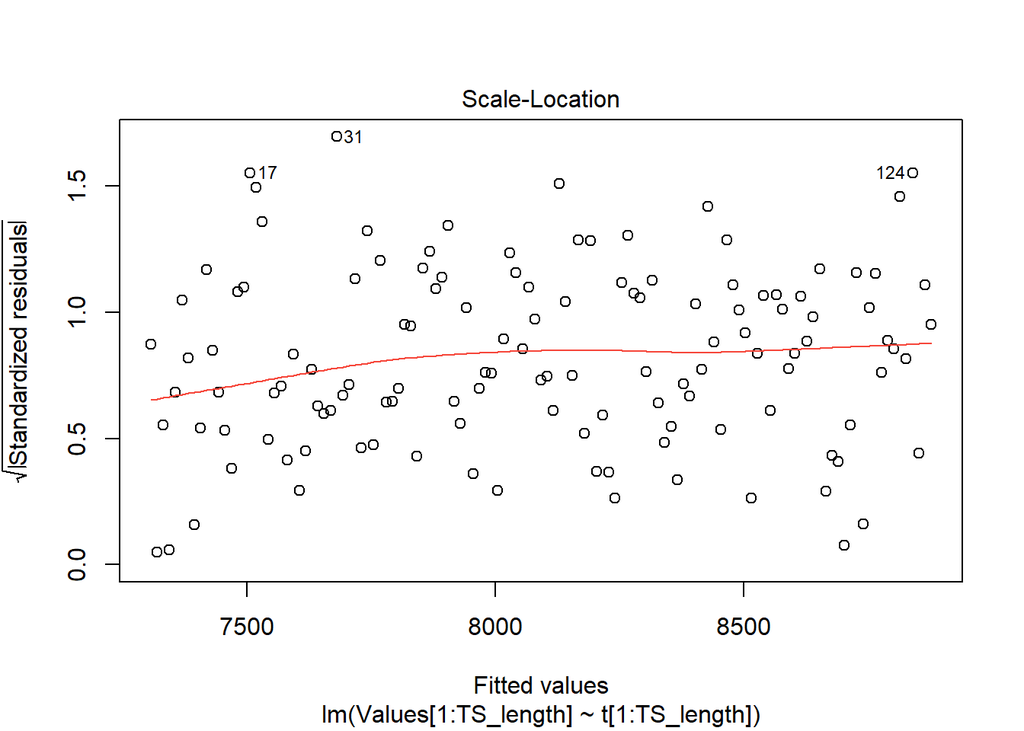

```r
plot(MNM38_lm,3)
```

Si è osservato che i punti sono equamente distribuiti attorno a una linea orizzontale, senza evidenza di schemi distinti. Questo è una prima evidenza visiva dell’omoshedasticità nei residui. Inoltre, si è notato una curva LOESS rossa molto vicina alla linea orizzontale, questa è un’altra prova visiva dell’assenza di eteroshedasticità.

Si è passato a disegnare uno scatter plot ed un line plot delle radici quadrate dei residui rispetto ai valori fittati:

```r
# Data preparation
length <- nrow(MNM38_df)
MNM38_lm_sqrt_abs_residuals <- c(as.vector(sqrt(abs(MNM38_res))), rep(NA, (length-TS_length)))
MNM38_df <- add_column(MNM38_df, MNM38_lm_sqrt_abs_res=MNM38_lm_sqrt_abs_residuals, .after="MNM38_lm_res")
head(MNM38_df)
```

```
##   t Year Month Values MNM38_lm_fit MNM38_lm_res MNM38_lm_sqrt_abs_res
## 1 1 1977   Dec   8458     7306.746  1151.254183             33.930137
## 2 2 1978   Jan   7323     7319.208     3.792206              1.947359
## 3 3 1978   Feb   7796     7331.670   464.330228             21.548323
## 4 4 1978   Mar   7339     7344.132    -5.131749              2.265336
## 5 5 1978   Apr   6650     7356.594  -706.593727             26.581831
## 6 6 1978   May   9032     7369.056  1662.944296             40.779214
```

```r
# Aggiorno il dataset di training
MNM38_train_df <- MNM38_df[1:TS_length,]
head(MNM38_train_df)
```

```
##   t Year Month Values MNM38_lm_fit MNM38_lm_res MNM38_lm_sqrt_abs_res
## 1 1 1977   Dec   8458     7306.746  1151.254183             33.930137
## 2 2 1978   Jan   7323     7319.208     3.792206              1.947359
## 3 3 1978   Feb   7796     7331.670   464.330228             21.548323
## 4 4 1978   Mar   7339     7344.132    -5.131749              2.265336
## 5 5 1978   Apr   6650     7356.594  -706.593727             26.581831
## 6 6 1978   May   9032     7369.056  1662.944296             40.779214
```

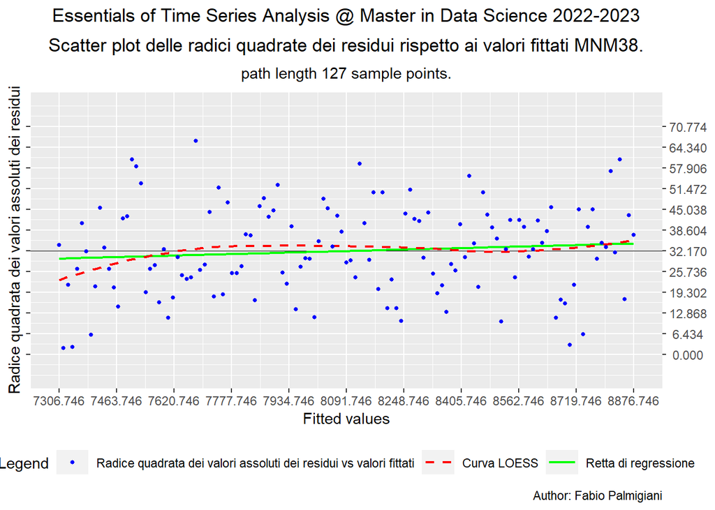

```r
# Scatter plot
Data_df  <- MNM38_train_df
length <- nrow(Data_df)
First_Date <- paste(Data_df$Month[1],Data_df$Year[1])
Last_Date <- paste(Data_df$Month[length],Data_df$Year[length])
title_content <- bquote(atop("Essentials of Time Series Analysis \u0040 Master in Data Science 2022-2023",
                             paste("Scatter plot delle radici quadrate dei residui rispetto ai valori fittati MNM38.")))
subtitle_content <- bquote(paste("path length ", .(length), " sample points."))
caption_content <- "Author: Fabio Palmigiani"
x_name <- bquote("Fitted values")
x_breaks_num <- 10
x_breaks_low <- min(Data_df$MNM38_lm_fit)
x_breaks_up <-  max(Data_df$MNM38_lm_fit)
x_binwidth <- round((x_breaks_up-x_breaks_low)/x_breaks_num, digits=1)
x_breaks <- seq(from=x_breaks_low, to=x_breaks_up, by=x_binwidth)
if((max(x_breaks)-x_breaks_up)>x_binwidth/2){x_breaks <- c(x_breaks,x_breaks_up)}
x_labs <- format(x_breaks, scientific=FALSE)
J <- 0
x_lims <- c(x_breaks_low-J*x_binwidth, x_breaks_up+J*x_binwidth)
y_name <- bquote("Radice quadrata dei valori assoluti dei residui")
y_breaks_num <- 10
y_binwidth <- round((max(Data_df$MNM38_lm_sqrt_abs_res)-min(Data_df$MNM38_lm_sqrt_abs_res))/y_breaks_num, digits=3)
y_breaks_low <- floor((min(Data_df$MNM38_lm_sqrt_abs_res)/y_binwidth))*y_binwidth
y_breaks_up <- ceiling((max(Data_df$MNM38_lm_sqrt_abs_res)/y_binwidth))*y_binwidth
y_breaks <- round(seq(from=y_breaks_low, to=y_breaks_up, by=y_binwidth),3)
y_labs <- format(y_breaks, scientific=FALSE)
K <- 1.0
y_lims <- c((y_breaks_low-K*y_binwidth), (y_breaks_up+K*y_binwidth))
col_1 <- bquote("Radice quadrata dei valori assoluti dei residui vs valori fittati")
col_2 <- bquote("Curva LOESS")
col_3 <- bquote("Retta di regressione")
leg_labs <- c(col_1, col_2, col_3)
leg_cols <- c("col_1"="blue", "col_2"="red", "col_3"="green")
leg_breaks <- c("col_1", "col_2", "col_3")
MNM38_Sqrt_Abs_Res_sp <- ggplot(Data_df) +
  geom_hline(yintercept = mean(Data_df$MNM38_lm_sqrt_abs_res), size=0.3, colour="black") +
  geom_smooth(alpha=1, size = 0.8, linetype="solid", aes(x=MNM38_lm_fit, y=MNM38_lm_sqrt_abs_res, color="col_3"),
              method = "lm" , formula = y ~ x, se=FALSE, fullrange=TRUE) +
  geom_smooth(alpha=1, size = 0.8, linetype="dashed", aes(x=MNM38_lm_fit, y=MNM38_lm_sqrt_abs_res, color="col_2"),
              method = "loess", formula = y ~ x, se=FALSE) +
  geom_point(alpha=1, size=1.0, shape=19, aes(x=MNM38_lm_fit, y=MNM38_lm_sqrt_abs_res, color="col_1")) +
  scale_x_continuous(name=x_name, breaks=x_breaks, label=x_labs, limits=x_lims) +
  scale_y_continuous(name=y_name, breaks=y_breaks, labels=NULL, limits=y_lims,
                     sec.axis = sec_axis(~., breaks=y_breaks, labels=y_labs)) +
  ggtitle(title_content) +
  labs(subtitle=subtitle_content, caption=caption_content) +
  scale_colour_manual(name="Legend", labels=leg_labs, values=leg_cols, breaks=leg_breaks,
                      guide=guide_legend(override.aes=list(shape=c(19,NA,NA),
                                                           linetype=c("blank", "dashed", "solid")))) +
  theme(plot.title=element_text(hjust=0.5), plot.subtitle=element_text(hjust=0.5),
        axis.text.x = element_text(angle=0, vjust=1),
        legend.key.width = unit(0.8,"cm"), legend.position="bottom")
plot(MNM38_Sqrt_Abs_Res_sp)
```

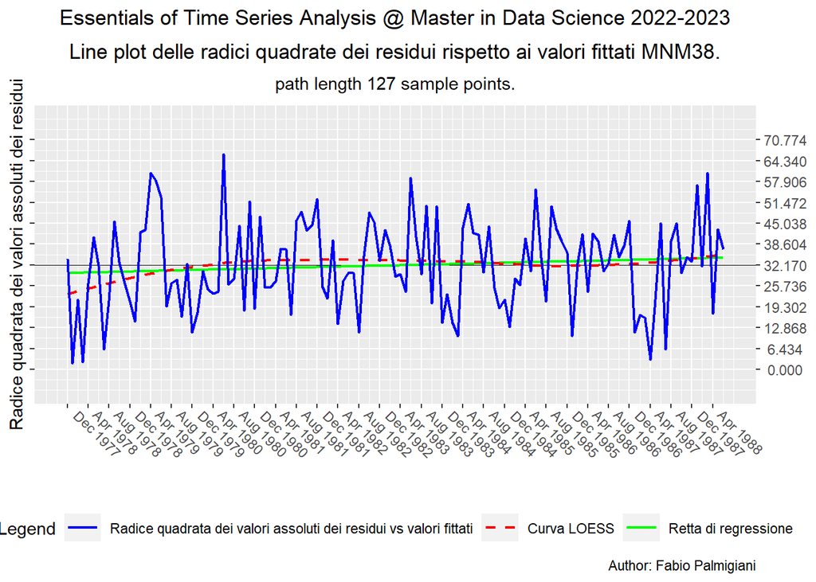

```r
# Line plot
Data_df <- MNM38_train_df
length <- nrow(Data_df)
First_Date <- paste(Data_df$Month[1],Data_df$Year[1])
Last_Date <- paste(Data_df$Month[length],Data_df$Year[length])
title_content <- bquote(atop("Essentials of Time Series Analysis \u0040 Master in Data Science 2022-2023",
                             paste("Line plot delle radici quadrate dei residui rispetto ai valori fittati MNM38.")))
x_name <- bquote("")
x_breaks_num <- 30
x_breaks_low <- Data_df$t[1]
x_breaks_up <- Data_df$t[length]
x_binwidth <- floor((x_breaks_up-x_breaks_low)/x_breaks_num)
x_breaks <- seq(from=x_breaks_low, to=x_breaks_up, by=x_binwidth)
if((max(x_breaks)-x_breaks_up)>x_binwidth/2){x_breaks <- c(x_breaks,x_breaks_up)}
x_labs <- paste(Data_df$Month[x_breaks],Data_df$Year[x_breaks])
J <- 0
x_lims <- c(x_breaks_low-J*x_binwidth, x_breaks_up+J*x_binwidth)
y_breaks_num <- 10
y_binwidth <- round((max(Data_df$MNM38_lm_sqrt_abs_res)-min(Data_df$MNM38_lm_sqrt_abs_res))/y_breaks_num, digits=3)
y_breaks_low <- floor((min(Data_df$MNM38_lm_sqrt_abs_res)/y_binwidth))*y_binwidth
y_breaks_up <- ceiling((max(Data_df$MNM38_lm_sqrt_abs_res)/y_binwidth))*y_binwidth
y_breaks <- round(seq(from=y_breaks_low, to=y_breaks_up, by=y_binwidth),3)
y_labs <- format(y_breaks, scientific=FALSE)
K <- 1.0
y_lims <- c((y_breaks_low-K*y_binwidth), (y_breaks_up+K*y_binwidth))
leg_labs   <- c(col_1, col_2, col_3)
leg_cols   <- c("col_1"="blue", "col_2"="red", "col_3"="green")
leg_breaks <- c("col_1", "col_2", "col_3")
MNM38_Sqrt_Abs_Res_lp <- ggplot(Data_df) +
  geom_hline(yintercept = mean(Data_df$MNM38_lm_sqrt_abs_res), size=0.3, colour="black") +
  geom_smooth(alpha=1, size = 0.8, linetype="solid", aes(x=t, y=MNM38_lm_sqrt_abs_res, color="col_3"),
              method = "lm" , formula = y ~ x, se=FALSE, fullrange=TRUE) +
  geom_smooth(alpha=1, size = 0.8, linetype="dashed", aes(x=t, y=MNM38_lm_sqrt_abs_res, color="col_2"),
              method = "loess", formula = y ~ x, se=FALSE) +
  geom_line(alpha=1, size=0.8, linetype="solid", aes(x=t, y=MNM38_lm_sqrt_abs_res, color="col_1")) +
  scale_x_continuous(name=x_name, breaks=x_breaks, label=x_labs, limits=x_lims) +
  scale_y_continuous(name=y_name, breaks=y_breaks, labels=NULL, limits=y_lims,
                     sec.axis = sec_axis(~., breaks=y_breaks, labels=y_labs)) +
  ggtitle(title_content) +
  labs(subtitle=subtitle_content, caption=caption_content) +
  scale_colour_manual(name="Legend", labels=leg_labs, values=leg_cols, breaks=leg_breaks,
                      guide=guide_legend(override.aes=list(linetype=c("solid", "dashed", "solid")))) +
  theme(plot.title=element_text(hjust=0.5), plot.subtitle=element_text(hjust=0.5),
        axis.text.x = element_text(angle=-45, vjust=1, hjust=-0.3),
        legend.key.width = unit(0.8,"cm"), legend.position="bottom")
plot(MNM38_Sqrt_Abs_Res_lp)
```

Si è passato a studiare in maniera computazionale l’omoshedasticità dei residui, effettuando il test di reusch-Pagan e il W test:

```r
Data_df  <- data.frame(x=MNM38_train_df$t, y=MNM38_train_df$Values, y_fit=MNM38_train_df$MNM38_lm_fit, y_res=MNM38_train_df$MNM38_lm_res)
# Breusch-Pagan test
lmtest::bptest(formula = y~x, varformula = NULL, studentize = TRUE, data=Data_df)
```

```
##
##  studentized Breusch-Pagan test
##
## data:  y ~ x
## BP = 0.072601, df = 1, p-value = 0.7876
```

```r
# W Test
var.formula <- ~ x+I(x^2)
lmtest::bptest(formula = y ~ x, varformula = var.formula, studentize = TRUE, data=Data_df)
```

```
##
##  studentized Breusch-Pagan test
##
## data:  y ~ x
## BP = 0.080211, df = 2, p-value = 0.9607
```

entrambi i test hanno un p-value alto, quindi non possimao rifiutare l’ipotesti di omoschedasticità.

Per studiare l’autocerrelazione dei residui si è disegnato l’autocorrelogramma:

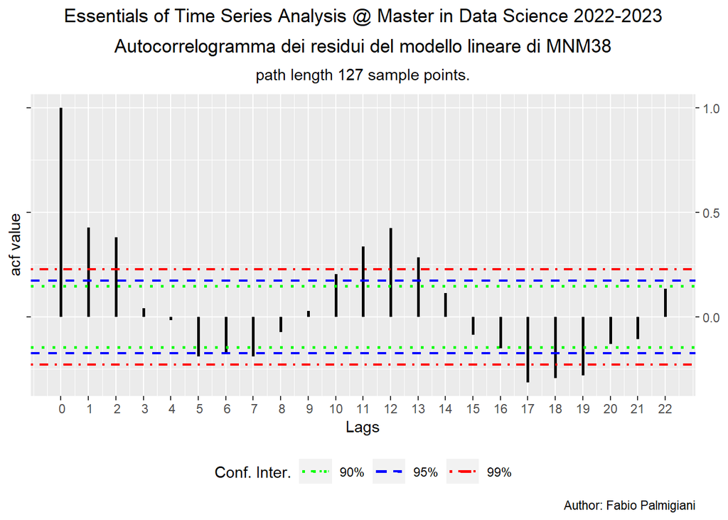

```r
# Autocorrelogramma
Data_df <-  MNM38_train_df
y <-  Data_df$MNM38_lm_res
T <- length(y)
maxlag <- ceiling(10*log10(T))
Aut_Fun_y_acf <- acf(y, lag.max=maxlag, type="correlation", plot=FALSE)
ci_90 <- qnorm((1+0.90)/2)/sqrt(T)
ci_95 <- qnorm((1+0.95)/2)/sqrt(T)
ci_99 <- qnorm((1+0.99)/2)/sqrt(T)
Aut_Fun_y_df <- data.frame(lag=Aut_Fun_y_acf$lag, acf=Aut_Fun_y_acf$acf)
First_Date <- paste(Data_df$Month[1],Data_df$Year[1])
Last_Date <- paste(Data_df$Month[length],Data_df$Year[length])
title_content <- bquote(atop("Essentials of Time Series Analysis \u0040 Master in Data Science 2022-2023",
                             paste("Autocorrelogramma dei residui del modello lineare di MNM38")))
x_name <- bquote("Lags")
x_breaks_num <- maxlag
x_binwidth <- 1
x_breaks <- Aut_Fun_y_acf$lag
x_labs <- format(x_breaks, scientific=FALSE)
y_name <- bquote("acf value")
Aut_Corr_Res_bp <- ggplot(Aut_Fun_y_df, aes(x=lag, y=acf)) +
  geom_segment(aes(x=lag, y=rep(0,length(lag)), xend=lag, yend=acf), size=1, col="black") +
  geom_hline(aes(yintercept=-ci_90, color="CI_90"), show.legend=TRUE, lwd=0.9, lty=3) +
  geom_hline(aes(yintercept=ci_90, color="CI_90"), lwd=0.9, lty=3) +
  geom_hline(aes(yintercept=ci_95, color="CI_95"), show.legend=TRUE, lwd=0.8, lty=2) +
  geom_hline(aes(yintercept=-ci_95, color="CI_95"), lwd=0.8, lty=2) +
  geom_hline(aes(yintercept=-ci_99, color="CI_99"), show.legend=TRUE, lwd=0.8, lty=4) +
  geom_hline(aes(yintercept=ci_99, color="CI_99"), lwd=0.8, lty=4) +
  scale_x_continuous(name=x_name, breaks=x_breaks, label=x_labs) +
  scale_y_continuous(name="acf value", breaks=waiver(), labels=NULL,
                     sec.axis=sec_axis(~., breaks=waiver(), labels=waiver())) +
  scale_colour_manual(name="Conf. Inter.", labels=c("90%","95%","99%"), values=c(CI_90="green", CI_95="blue", CI_99="red"),
                      guide=guide_legend(override.aes=list(linetype=c("dotted", "dashed", "dotdash")))) +
  ggtitle(title_content) +
  labs(subtitle=subtitle_content, caption=caption_content) +
  theme(plot.title=element_text(hjust=0.5),
        plot.subtitle=element_text(hjust= 0.5),
        plot.caption=element_text(hjust=1.0),
        legend.key.width=unit(0.8,"cm"), legend.position="bottom")
plot(Aut_Corr_Res_bp)
```

Dall’autocorrelogramma si evince una forte presenza di stagionalità, tanto da rendere inutile studiare l’autocorrelogramma parziale. Per confermare questa evidenza si è effettuato il test di Ljung-Box (LB):

```r
# Ljung-Box (LB) test
Data_df <-  MNM38_train_df
y <- Data_df$MNM38_lm_res
T <- length(y)
maxlag <- ceiling(min(2*12, T/5))
y_LB <- LjungBoxTest(y, k=1, lag.max=maxlag, StartLag=1, SquaredQ=FALSE)
show(y_LB)
```

```
##   m     Qm       pvalue
##   1  23.63 1.169676e-06
##   2  42.54 6.917888e-11
##   3  42.77 5.150878e-10
##   4  42.81 2.701169e-09
##   5  47.65 1.118212e-09
##   6  51.66 6.331197e-10
##   7  56.58 2.220604e-10
##   8  57.31 5.193068e-10
##   9  57.42 1.488052e-09
##  10  63.24 3.163833e-10
##  11  79.27 6.981082e-13
##  12 104.96 0.000000e+00
##  13 116.50 0.000000e+00
##  14 118.39 0.000000e+00
##  15 119.50 0.000000e+00
##  16 122.82 0.000000e+00
##  17 137.49 0.000000e+00
##  18 150.42 0.000000e+00
##  19 162.26 0.000000e+00
##  20 164.87 0.000000e+00
##  21 166.65 0.000000e+00
##  22 169.45 0.000000e+00
##  23 173.58 0.000000e+00
##  24 190.22 0.000000e+00
```

Il test conferma una forte autocorrelazione dei residui.

A questo punto, si è tornato alla serie originale.

Siccome l’unica cosa che bisogna cercare di eliminare è la forte presenza di stagionalità, visto che i residui risultavano essere omoschedastici e stazionari, non c’è stata la necessità di fare la trasformazione in Box-Cox, ma si è proceduto con la decomposizione della serie.

### Decomposizione

In questa fase si sono tolte le componenti di trend e stagionalità dalla serie.

Prima il trend:

```r
y <- MNM38_train_df$Values
MNM38_train_df_ts = ts(y, frequency=12, start=c(1977,12))
# Trasformazione in matrice
MNM38_train_mat <- t(matrix(as.vector(MNM38_train_df_ts), nrow=12))

MNM38_ann_av_vec <- rowMeans(MNM38_train_mat, na.rm=TRUE)

MNM38_trend_vec <- rep(MNM38_ann_av_vec, each=12)

MNM38_trend_ts <- ts(MNM38_trend_vec, start=c(1977,12), frequency=12)
```

Grafico della componente media annua del terend e della componente trend della serie storica:

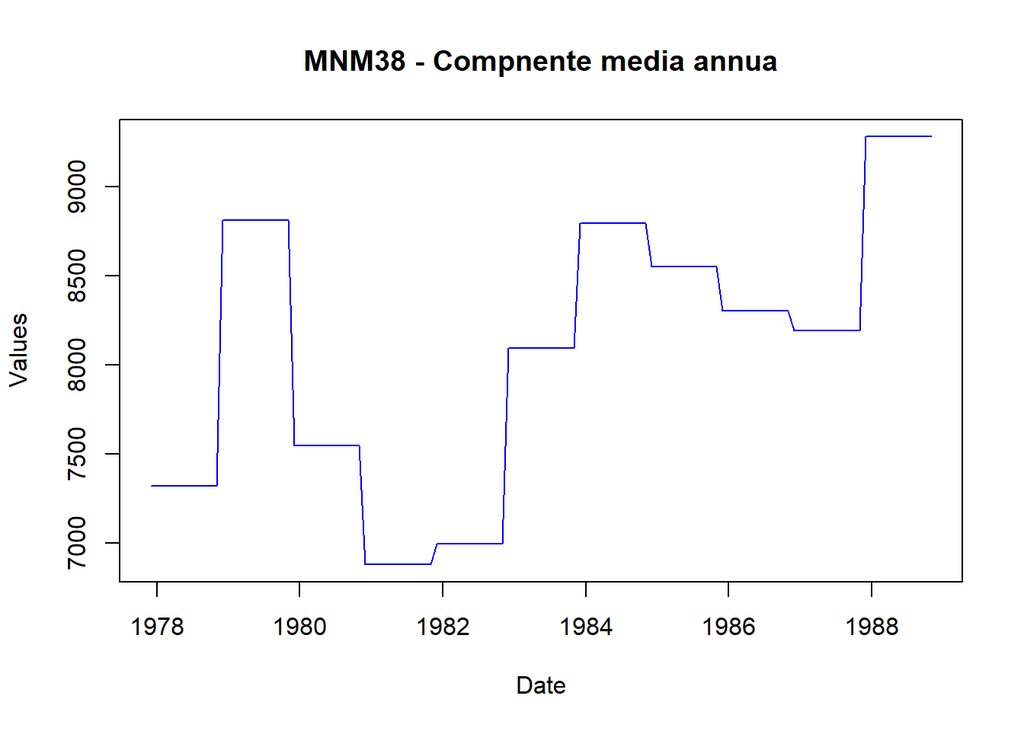

```r
# Plot della componente trend
plot(MNM38_trend_ts, type="l", col="blue", xlab="Date", ylab="Values", main="MNM38 - Compnente media annua")
```

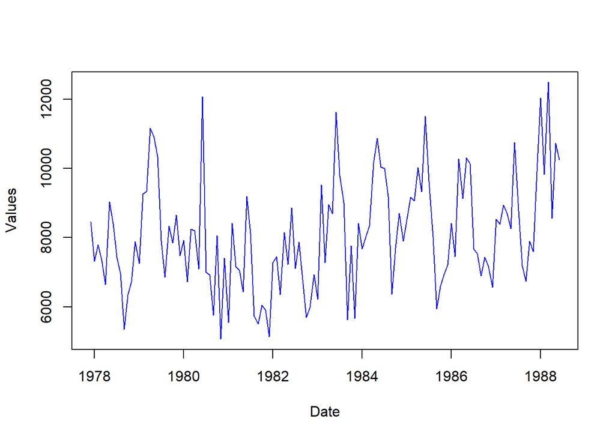

```r
plot(MNM38_train_df_ts, type="l", col="blue", xlab="Date", ylab="Values")
```

Si è rimosso quindi il trend dalla serie:

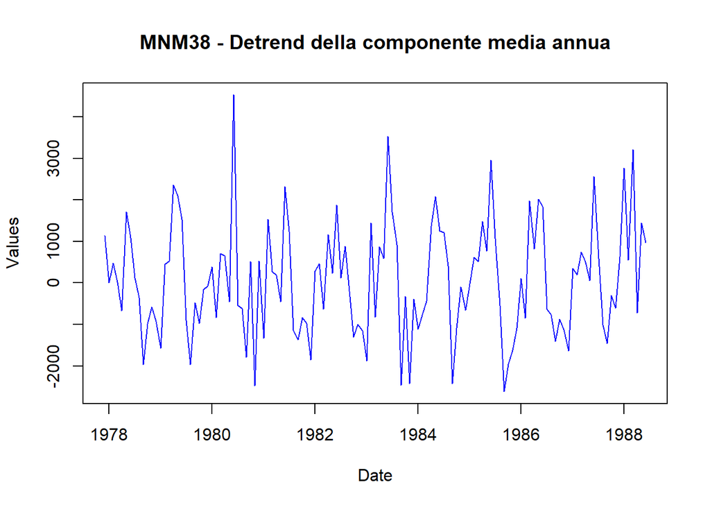

```r
# Rimozione del trend
MNM38_det_ts <- MNM38_train_df_ts-MNM38_trend_ts

# Plot della serie detrendizzata
plot(MNM38_det_ts, col="blue", xlab="Date", ylab="Values", main="MNM38 - Detrend della componente media annua")
```

Ora si sono effettuati gli stessi passaggi per eliminare la stagionalità dalla serie:

```r
MNM38_det_mat <- t(matrix(as.vector(MNM38_det_ts), nrow=12))

MNM38_monthly_av_vec <- colMeans(MNM38_det_mat, na.rm=TRUE)

MNM38_seas_vec <- rep(MNM38_monthly_av_vec, times=nrow(MNM38_train_mat))

MNM38_seas_ts <- ts(MNM38_seas_vec, start=c(1977,12), frequency=12)
```

Componente di stagionalità della serie:

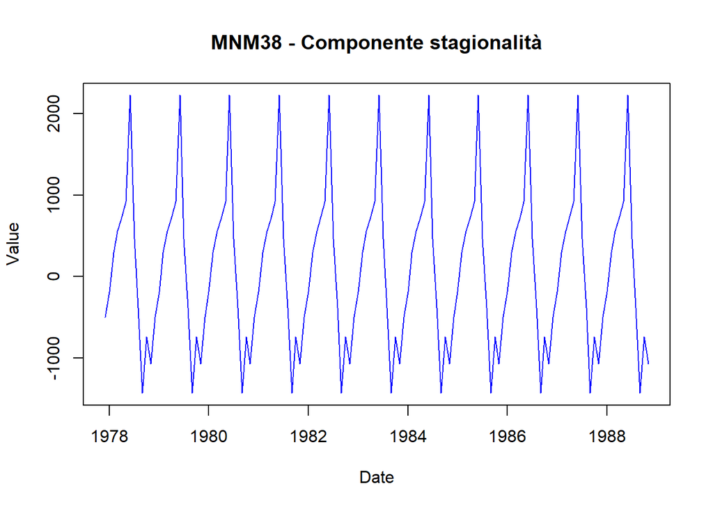

```r
plot(MNM38_seas_ts, col="blue", xlab="Date", ylab="Value", main="MNM38 - Componente stagionalità")
```

Si è proceduto con la costruzione del dataset destagionalizzato:

```r
MNM38_deseas_ts <- MNM38_ts-MNM38_seas_ts
```

Gragico della serie destagionalizzata:

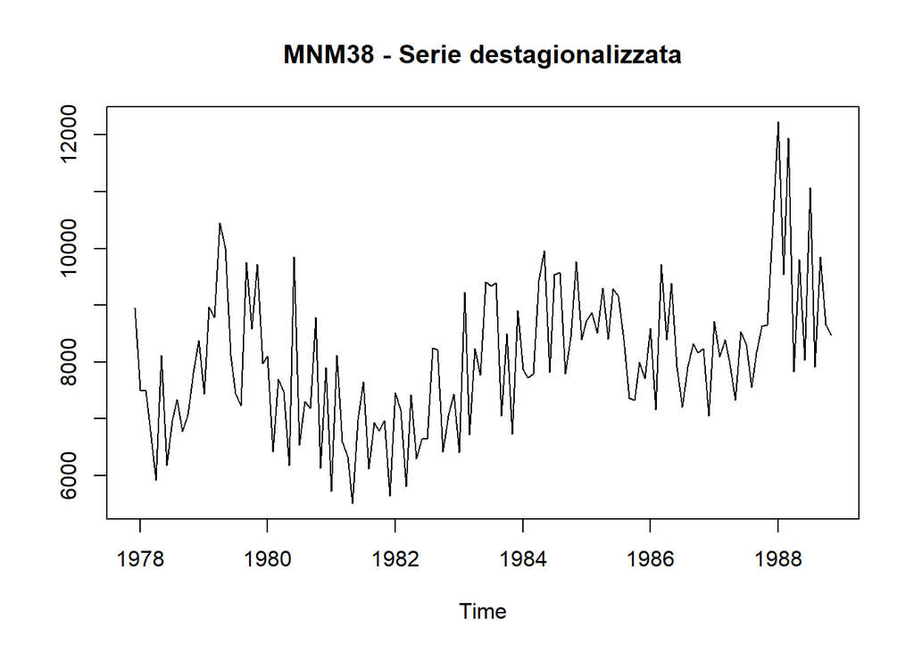

```r
plot(MNM38_deseas_ts, xlab="Time", ylab="", main="MNM38 - Serie destagionalizzata")
```

Infine si è costruito la serie detrendizzata e destagionalizzata, ovvero la componente residua della time series:

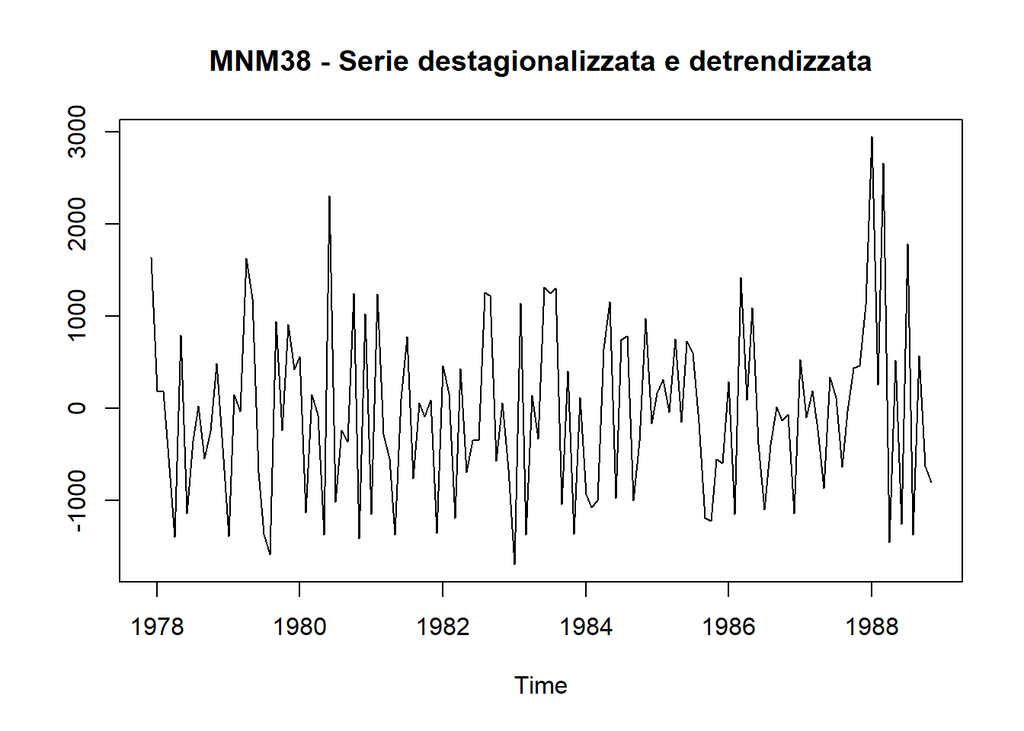

```r
MNM38_res_ts <- MNM38_ts - MNM38_trend_ts - MNM38_seas_ts
plot(MNM38_res_ts, xlab="Time", ylab="", main="MNM38 - Serie destagionalizzata e detrendizzata")
```

```r
# memorizzo il risultato della decomposizione in un dataframe
MNM38_dec_df <- data.frame(t=MNM38_train_df$t, Year=MNM38_train_df$Year, Month=MNM38_train_df$Month, y=MNM38_train_df$Values, y_trend=as.vector(MNM38_trend_ts)[1:127], y_seas=as.vector(MNM38_seas_ts)[1:127],
                               y_res=as.vector(MNM38_res_ts)[1:127], y_det=as.vector(MNM38_det_ts)[1:127], y_deseas=as.vector(MNM38_deseas_ts)[1:127])
```

### Studio dei residui della serie destagionalizzata e detrendizzata

Line plot del rumore della serie:

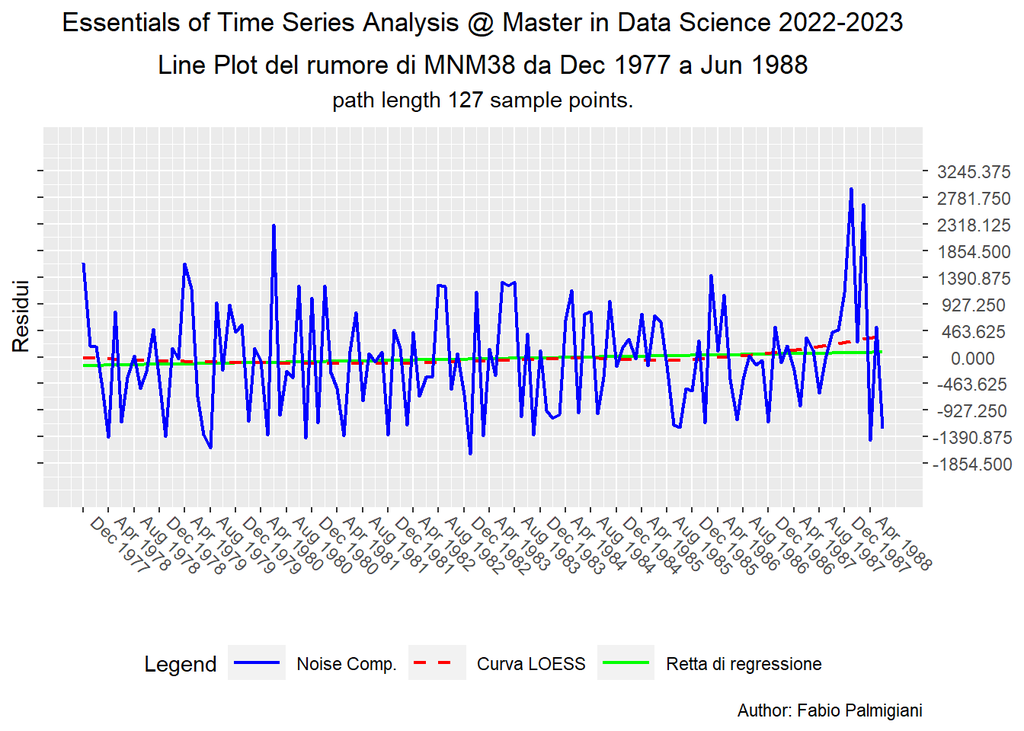

```r
# Line plot
Data_df <- MNM38_dec_df
length <- nrow(Data_df)
First_Date <- paste(Data_df$Month[1],Data_df$Year[1])
Last_Date <- paste(Data_df$Month[length],Data_df$Year[length])
title_content <- bquote(atop("Essentials of Time Series Analysis \u0040 Master in Data Science 2022-2023",
                             paste("Line Plot del rumore di MNM38 da ", .(First_Date), " a ", .(Last_Date))))
subtitle_content <- bquote(paste("path length ", .(length), " sample points."))
caption_content <- "Author: Fabio Palmigiani"
x_name <- bquote("")
y_name <- bquote("Residui")
x_breaks_num <- 30
x_breaks_low <- Data_df$t[1]
x_breaks_up <- Data_df$t[length]
x_binwidth <- floor((x_breaks_up-x_breaks_low)/x_breaks_num)
x_breaks <- seq(from=x_breaks_low, to=x_breaks_up, by=x_binwidth)
if((max(x_breaks)-x_breaks_up)>x_binwidth/2){x_breaks <- c(x_breaks,x_breaks_up)}
x_labs <- paste(Data_df$Month[x_breaks],Data_df$Year[x_breaks])
J <- 0
x_lims <- c(x_breaks_low-J*x_binwidth, x_breaks_up+J*x_binwidth)
y_breaks_num <- 10
y_binwidth <- round((max(Data_df$y_res)-min(Data_df$y_res))/y_breaks_num, digits=3)
y_breaks_low <- floor((min(Data_df$y_res)/y_binwidth))*y_binwidth
y_breaks_up <- ceiling((max(Data_df$y_res)/y_binwidth))*y_binwidth
y_breaks <- round(seq(from=y_breaks_low, to=y_breaks_up, by=y_binwidth),3)
y_labs <- format(y_breaks, scientific=FALSE)
K <-  1
y_lims <- c((y_breaks_low-K*y_binwidth), (y_breaks_up+K*y_binwidth))
col_1 <- bquote("Noise Comp.")
col_2 <- bquote("Curva LOESS")
col_3 <- bquote("Retta di regressione")
leg_labs <- c(col_1, col_2, col_3)
leg_cols <- c("col_1"="blue", "col_2"="red", "col_3"="green")
leg_breaks <- c("col_1", "col_2", "col_3")
MNM38_res_lp <- ggplot(Data_df) +
  geom_smooth(alpha=1, size = 0.8, linetype="solid", aes(x=t, y=y_res, color="col_3"),
              method = "lm" , formula = y ~ x, se=FALSE, fullrange=TRUE) +
  geom_smooth(alpha=1, size = 0.8, linetype="dashed", aes(x=t, y=y_res, color="col_2"),
              method = "loess", formula = y ~ x, se=FALSE) +
  geom_line(alpha=1, size=0.8, linetype="solid", aes(x=t, y=y_res, color="col_1", group=1)) +
  scale_x_continuous(name=x_name, breaks=x_breaks, label=x_labs, limits=x_lims) +
  scale_y_continuous(name=y_name, breaks=y_breaks, labels=NULL, limits=y_lims,
                     sec.axis = sec_axis(~., breaks=y_breaks, labels=y_labs)) +
  ggtitle(title_content) +
  labs(subtitle=subtitle_content, caption=caption_content) +
  scale_colour_manual(name="Legend", labels=leg_labs, values=leg_cols, breaks=leg_breaks,
                      guide=guide_legend(override.aes=list(linetype=c("solid", "dashed", "solid")))) +
  theme(plot.title=element_text(hjust=0.5), plot.subtitle=element_text(hjust=0.5),
        axis.text.x = element_text(angle=-45, vjust=1, hjust=-0.3),
        legend.key.width = unit(1.0,"cm"), legend.position="bottom")
plot(MNM38_res_lp)
```

Si è eseguito il test di stazionarietà:

```r
# ADF Test
Res_DF_none <- ur.df(MNM38_dec_df$y_res, type="none", lags=0, selectlags="Fixed")
summary(Res_DF_none)
```

```
##
## ###############################################
## # Augmented Dickey-Fuller Test Unit Root Test #
## ###############################################
##
## Test regression none
##
##
## Call:
## lm(formula = z.diff ~ z.lag.1 - 1)
##
## Residuals:
##      Min       1Q   Median       3Q      Max
## -1768.66  -665.95   -51.08   523.01  3077.12
##
## Coefficients:
##         Estimate Std. Error t value Pr(>|t|)
## z.lag.1 -1.11737    0.08836  -12.65   <2e-16 ***
## ---
## Signif. codes:  0 '***' 0.001 '**' 0.01 '*' 0.05 '.' 0.1 ' ' 1
##
## Residual standard error: 914.7 on 125 degrees of freedom
## Multiple R-squared:  0.5613, Adjusted R-squared:  0.5578
## F-statistic: 159.9 on 1 and 125 DF,  p-value: < 2.2e-16
##
##
## Value of test-statistic is: -12.6462
##
## Critical values for test statistics:
##       1pct  5pct 10pct
## tau1 -2.58 -1.95 -1.62
```

```r
# KPSS Test
Res_KPSS_mu <- ur.kpss(MNM38_dec_df$y_res, type="mu", lags="nil", use.lag=NULL)
summary(Res_KPSS_mu)
```

```
##
## #######################
## # KPSS Unit Root Test #
## #######################
##
## Test is of type: mu with 0 lags.
##
## Value of test-statistic is: 0.0941
##
## Critical value for a significance level of:
##                 10pct  5pct 2.5pct  1pct
## critical values 0.347 0.463  0.574 0.739
```

Come ci si aspettava, i residui sono stati generati da rumori stazionari.

Si è proceduto con i test di omoschedasticità:

```r
Data_df <- data.frame(x=MNM38_dec_df$t,y=MNM38_dec_df$y_res)
lmtest::bptest(formula = y~x, varformula = NULL, studentize = TRUE, data=Data_df)
```

```
##
##  studentized Breusch-Pagan test
##
## data:  y ~ x
## BP = 0.17008, df = 1, p-value = 0.68
```

```r
var.formula <- ~ x+I(x^2)
lmtest::bptest(formula = y ~ x, varformula = var.formula, studentize = TRUE, data=Data_df)
```

```
##
##  studentized Breusch-Pagan test
##
## data:  y ~ x
## BP = 2.3043, df = 2, p-value = 0.316
```

quindi non è stato possibile rifiutare l’ipotesti di omoschedasticità.

In modo tale da avere evidenza visiva del fatto che essi siano autocorrelati o meno, si è disegnato l’autocorrelogramma e l’autocorrelogramma parziale dei residui:

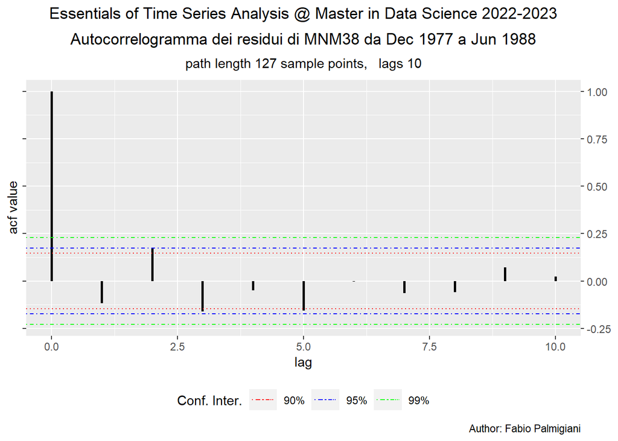

```r
# Autocorrelogramma
Data_df <- MNM38_dec_df
y <- Data_df$y_res
length <- length(y)
T <- length
maxlag <- ceiling(min(10, T/4))
Aut_Fun_y <- acf(y, lag.max = maxlag, type="correlation", plot=FALSE)
ci_90 <- qnorm((1+0.90)/2)/sqrt(length)
ci_95 <- qnorm((1+0.95)/2)/sqrt(length)
ci_99 <- qnorm((1+0.99)/2)/sqrt(length)
Plot_Aut_Fun_y <- data.frame(lag=Aut_Fun_y$lag, acf=Aut_Fun_y$acf)
First_Date <- paste(Data_df$Month[1],Data_df$Year[1])
Last_Date <- paste(Data_df$Month[length],Data_df$Year[length])
title_content <- bquote(atop("Essentials of Time Series Analysis \u0040 Master in Data Science 2022-2023",
                             paste("Autocorrelogramma dei residui di MNM38 da ", .(First_Date), " a ", .(Last_Date))))
subtitle_content <- bquote(paste("path length ", .(length), " sample points,   ", "lags ", .(maxlag)))
ggplot(Plot_Aut_Fun_y, aes(x=lag, y=acf)) +
  geom_segment(aes(x=lag, y=rep(0,length(lag)), xend=lag, yend=acf), size = 1, col="black") +
  geom_hline(aes(yintercept=-ci_90, color="CI_90"), show.legend = TRUE, lty=3) +
  geom_hline(aes(yintercept=ci_90, color="CI_90"), lty=3) +
  geom_hline(aes(yintercept=ci_95, color="CI_95"), show.legend = TRUE, lty=4) +
  geom_hline(aes(yintercept=-ci_95, color="CI_95"), lty=4) +
  geom_hline(aes(yintercept=-ci_99, color="CI_99"), show.legend = TRUE, lty=4) +
  geom_hline(aes(yintercept=ci_99, color="CI_99"), lty=4) +
  scale_x_continuous(name="lag", breaks=waiver(), label=waiver()) +
  scale_y_continuous(name="acf value", breaks=waiver(), labels=NULL,
                     sec.axis = sec_axis(~., breaks=waiver(), labels=waiver())) +
  scale_color_manual(name="Conf. Inter.", labels=c("90%","95%","99%"),
                     values=c(CI_90="red", CI_95="blue", CI_99="green")) +
  ggtitle(title_content) +
  labs(subtitle=subtitle_content, caption=caption_content) +
  theme(plot.title=element_text(hjust = 0.5),
        plot.subtitle=element_text(hjust =  0.5),
        plot.caption = element_text(hjust = 1.0),
        legend.key.width = unit(0.8,"cm"), legend.position="bottom")
```

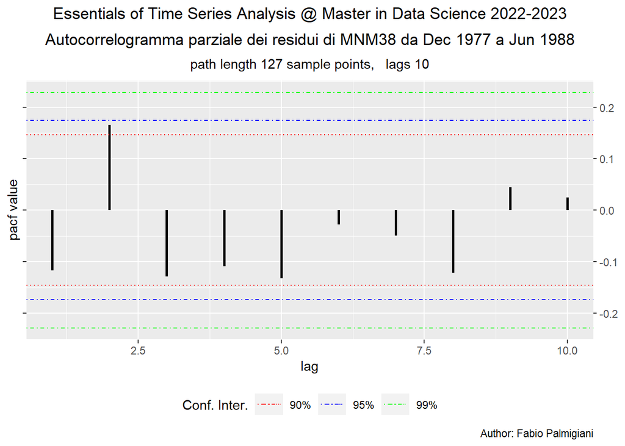

```r
# Autocottelogramma parziale
Data_df <- MNM38_dec_df
y <- Data_df$y_res
length <- length(y)
T <- length
maxlag <- ceiling(min(10, T/4))
P_Aut_Fun_y <- pacf(y, lag.max = maxlag, plot=FALSE)
ci_90 <- qnorm((1+0.90)/2)/sqrt(length)
ci_95 <- qnorm((1+0.95)/2)/sqrt(length)
ci_99 <- qnorm((1+0.99)/2)/sqrt(length)
Plot_P_Aut_Fun_y <- data.frame(lag=P_Aut_Fun_y$lag, pacf=P_Aut_Fun_y$acf)
First_Date <- paste(Data_df$Month[1],Data_df$Year[1])
Last_Date <- paste(Data_df$Month[length],Data_df$Year[length])
title_content <- bquote(atop("Essentials of Time Series Analysis \u0040 Master in Data Science 2022-2023",
                             paste("Autocorrelogramma parziale dei residui di MNM38 da ", .(First_Date), " a ", .(Last_Date))))
subtitle_content <- bquote(paste("path length ", .(length), " sample points,   ", "lags ", .(maxlag)))
ggplot(Plot_P_Aut_Fun_y, aes(x=lag, y=pacf)) +
  geom_segment(aes(x=lag, y=rep(0,length(lag)), xend=lag, yend=pacf), size = 1, col="black") +
  geom_hline(aes(yintercept=-ci_90, color="CI_90"), show.legend = TRUE, lty=3) +
  geom_hline(aes(yintercept=ci_90, color="CI_90"), lty=3) +
  geom_hline(aes(yintercept=ci_95, color="CI_95"), show.legend = TRUE, lty=4) +
  geom_hline(aes(yintercept=-ci_95, color="CI_95"), lty=4) +
  geom_hline(aes(yintercept=-ci_99, color="CI_99"), show.legend = TRUE, lty=4) +
  geom_hline(aes(yintercept=ci_99, color="CI_99"), lty=4) +
  scale_x_continuous(name="lag", breaks=waiver(), label=waiver()) +
  scale_y_continuous(name="pacf value", breaks=waiver(), labels=NULL,
                     sec.axis = sec_axis(~., breaks=waiver(), labels=waiver())) +
  scale_color_manual(name="Conf. Inter.", labels=c("90%","95%","99%"),
                     values=c(CI_90="red", CI_95="blue", CI_99="green")) +
  ggtitle(title_content) +
  labs(subtitle=subtitle_content, caption=caption_content) +
  theme(plot.title=element_text(hjust = 0.5),
        plot.subtitle=element_text(hjust =  0.5),
        plot.caption = element_text(hjust = 1.0),
        legend.key.width = unit(0.8,"cm"), legend.position="bottom")
```

A prima vista sembrerebbe esserci presenza di autocorrelazione, ma per esserne sicuri si è effettuato il test di Ljung-Box:

```r
T <- length(MNM38_dec_df$y_res)
maxlag <- ceiling(min(10, T/4))
y_LB <- LjungBoxTest(MNM38_dec_df$y_res, k=1, lag.max=maxlag, StartLag=1, SquaredQ=FALSE)
show(y_LB)
```

```
##   m    Qm      pvalue
##   1  1.79 0.181522706
##   2  5.87 0.015357638
##   3  9.25 0.009804974
##   4  9.56 0.022699724
##   5 12.88 0.011887555
##   6 12.88 0.024534951
##   7 13.44 0.036511332
##   8 13.92 0.052635913
##   9 14.64 0.066461781
##  10 14.71 0.099118863
```

Il test conferma una lieve presenza di autocorrelazione tra i residui.

Si è decide quindi di usare il modello ARIMA per descrivere la serie.

### Modello ARIMA

Si è autogenerato il miglior modello possibile per la serie:

```r
y <- as.vector(MNM38_dec_df$y_res)
AUTOARIMA_y_AIC <- auto.arima(y, start.p=0, max.p=6, start.q=0, max.q=6, max.order=12, ic="aic", allowmean=TRUE, trace =TRUE, stepwise=FALSE, nmodels =94, approximation=FALSE)
```

```
##
##  ARIMA(0,0,0) with zero mean     : 2097.262
##  ARIMA(0,0,0) with non-zero mean : 2099.105
##  ARIMA(0,0,1) with zero mean     : 2097.932
##  ARIMA(0,0,1) with non-zero mean : 2099.737
##  ARIMA(0,0,2) with zero mean     : 2096.037
##  ARIMA(0,0,2) with non-zero mean : 2097.923
##  ARIMA(0,0,3) with zero mean     : 2096.03
##  ARIMA(0,0,3) with non-zero mean : 2097.832
##  ARIMA(0,0,4) with zero mean     : 2096.289
##  ARIMA(0,0,4) with non-zero mean : 2097.899
##  ARIMA(0,0,5) with zero mean     : 2095.669
##  ARIMA(0,0,5) with non-zero mean : 2096.843
##  ARIMA(0,0,6) with zero mean     : 2097.516
##  ARIMA(0,0,6) with non-zero mean : 2098.83
##  ARIMA(1,0,0) with zero mean     : 2097.496
##  ARIMA(1,0,0) with non-zero mean : 2099.292
##  ARIMA(1,0,1) with zero mean     : 2095.723
##  ARIMA(1,0,1) with non-zero mean : 2097.544
##  ARIMA(1,0,2) with zero mean     : 2096.46
##  ARIMA(1,0,2) with non-zero mean : 2098.318
##  ARIMA(1,0,3) with zero mean     : 2094.185
##  ARIMA(1,0,3) with non-zero mean : Inf
##  ARIMA(1,0,4) with zero mean     : 2096.09
##  ARIMA(1,0,4) with non-zero mean : Inf
##  ARIMA(1,0,5) with zero mean     : 2097.033
##  ARIMA(1,0,5) with non-zero mean : 2098.444
##  ARIMA(1,0,6) with zero mean     : 2099.03
##  ARIMA(1,0,6) with non-zero mean : 2100.431
##  ARIMA(2,0,0) with zero mean     : 2095.814
##  ARIMA(2,0,0) with non-zero mean : 2097.684
##  ARIMA(2,0,1) with zero mean     : 2096.528
##  ARIMA(2,0,1) with non-zero mean : 2098.392
##  ARIMA(2,0,2) with zero mean     : 2098.454
##  ARIMA(2,0,2) with non-zero mean : 2100.314
##  ARIMA(2,0,3) with zero mean     : 2096.05
##  ARIMA(2,0,3) with non-zero mean : Inf
##  ARIMA(2,0,4) with zero mean     : 2097.901
##  ARIMA(2,0,4) with non-zero mean : Inf
##  ARIMA(2,0,5) with zero mean     : 2098.961
```

[output cut: 48 more lines]

```
##  ARIMA(6,0,1) with non-zero mean : Inf
##  ARIMA(6,0,2) with zero mean     : 2100.939
##  ARIMA(6,0,2) with non-zero mean : Inf
##  ARIMA(6,0,3) with zero mean     : Inf
##  ARIMA(6,0,3) with non-zero mean : Inf
##  ARIMA(6,0,4) with zero mean     : Inf
##  ARIMA(6,0,4) with non-zero mean : Inf
##  ARIMA(6,0,5) with zero mean     : Inf
##  ARIMA(6,0,5) with non-zero mean : Inf
##  ARIMA(6,0,6) with zero mean     : Inf
##  ARIMA(6,0,6) with non-zero mean : Inf
##
##
##
##  Best model: ARIMA(3,0,1) with zero mean
```

```r
show(AUTOARIMA_y_AIC)
```

```
## Series: y
## ARIMA(3,0,1) with zero mean
##
## Coefficients:
##          ar1     ar2      ar3      ma1
##       0.7247  0.2351  -0.2749  -0.8329
## s.e.  0.1703  0.1074   0.0894   0.1590
##
## sigma^2 = 803855:  log likelihood = -1041.77
## AIC=2093.54   AICc=2094.04   BIC=2107.76
```

Il miglior modello è risultato essere ARIMA(3,0,1).

Si è passato a studiare l’autocorrelazione dei residui del modello ARIMA(3,0,1), disegnando l’autocorrelogramma e l’autocorrelogramma parziale dei residui del modello ARIMA(3,0,1):

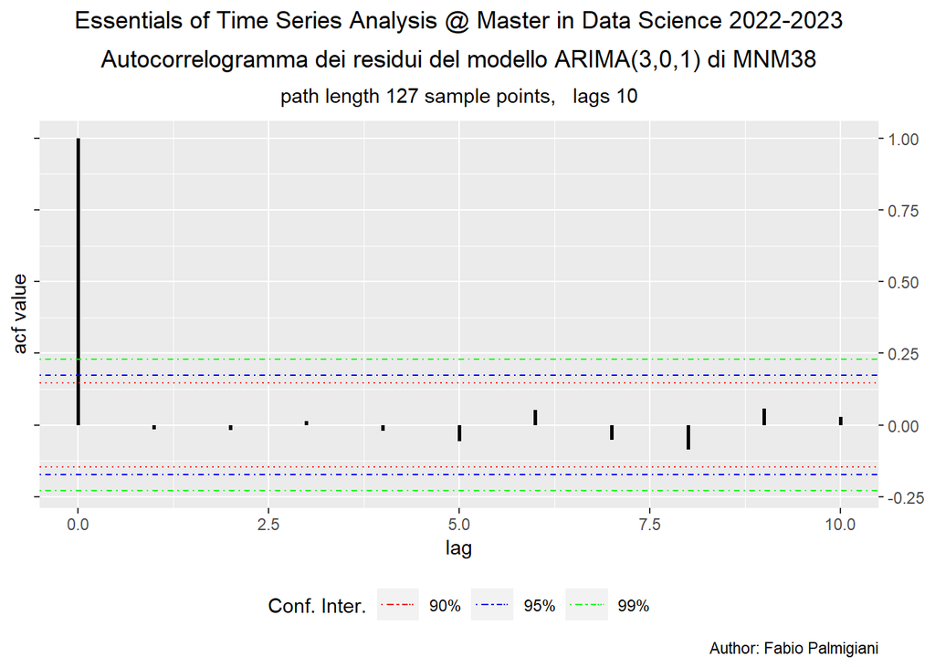

```r
# Autocorrelogramma
AUTOARMA_y_AIC_res_ts <- AUTOARIMA_y_AIC[["residuals"]]
AUTOARMA_y_AIC_res_vec <- as.vector(AUTOARMA_y_AIC_res_ts)
sum_pq <- length(AUTOARIMA_y_AIC[["coef"]])
y <- AUTOARMA_y_AIC_res_vec
length <- length(y)
T <- length
maxlag <- ceiling(min(10, T/4))
Aut_Fun_y <- acf(y, lag.max = maxlag, type="correlation", plot=FALSE)
ci_90 <- qnorm((1+0.90)/2)/sqrt(length)
ci_95 <- qnorm((1+0.95)/2)/sqrt(length)
ci_99 <- qnorm((1+0.99)/2)/sqrt(length)
Plot_Aut_Fun_y <- data.frame(lag=Aut_Fun_y$lag, acf=Aut_Fun_y$acf)
First_Date <- paste(Data_df$Month[1],Data_df$Year[1])
Last_Date <- paste(Data_df$Month[length],Data_df$Year[length])
title_content <- bquote(atop("Essentials of Time Series Analysis \u0040 Master in Data Science 2022-2023",
                             paste("Autocorrelogramma dei residui del modello ARIMA(3,0,1) di MNM38" )))
subtitle_content <- bquote(paste("path length ", .(length), " sample points,   ", "lags ", .(maxlag)))
ggplot(Plot_Aut_Fun_y, aes(x=lag, y=acf)) +
  geom_segment(aes(x=lag, y=rep(0,length(lag)), xend=lag, yend=acf), size = 1, col="black") +
  geom_hline(aes(yintercept=-ci_90, color="CI_90"), show.legend = TRUE, lty=3) +
  geom_hline(aes(yintercept=ci_90, color="CI_90"), lty=3) +
  geom_hline(aes(yintercept=ci_95, color="CI_95"), show.legend = TRUE, lty=4) +
  geom_hline(aes(yintercept=-ci_95, color="CI_95"), lty=4) +
  geom_hline(aes(yintercept=-ci_99, color="CI_99"), show.legend = TRUE, lty=4) +
  geom_hline(aes(yintercept=ci_99, color="CI_99"), lty=4) +
  scale_x_continuous(name="lag", breaks=waiver(), label=waiver()) +
  scale_y_continuous(name="acf value", breaks=waiver(), labels=NULL,
                     sec.axis = sec_axis(~., breaks=waiver(), labels=waiver())) +
  scale_color_manual(name="Conf. Inter.", labels=c("90%","95%","99%"),
                     values=c(CI_90="red", CI_95="blue", CI_99="green")) +
  ggtitle(title_content) +
  labs(subtitle=subtitle_content, caption=caption_content) +
  theme(plot.title=element_text(hjust = 0.5),
        plot.subtitle=element_text(hjust =  0.5),
        plot.caption = element_text(hjust = 1.0),
        legend.key.width = unit(0.8,"cm"), legend.position="bottom")
```

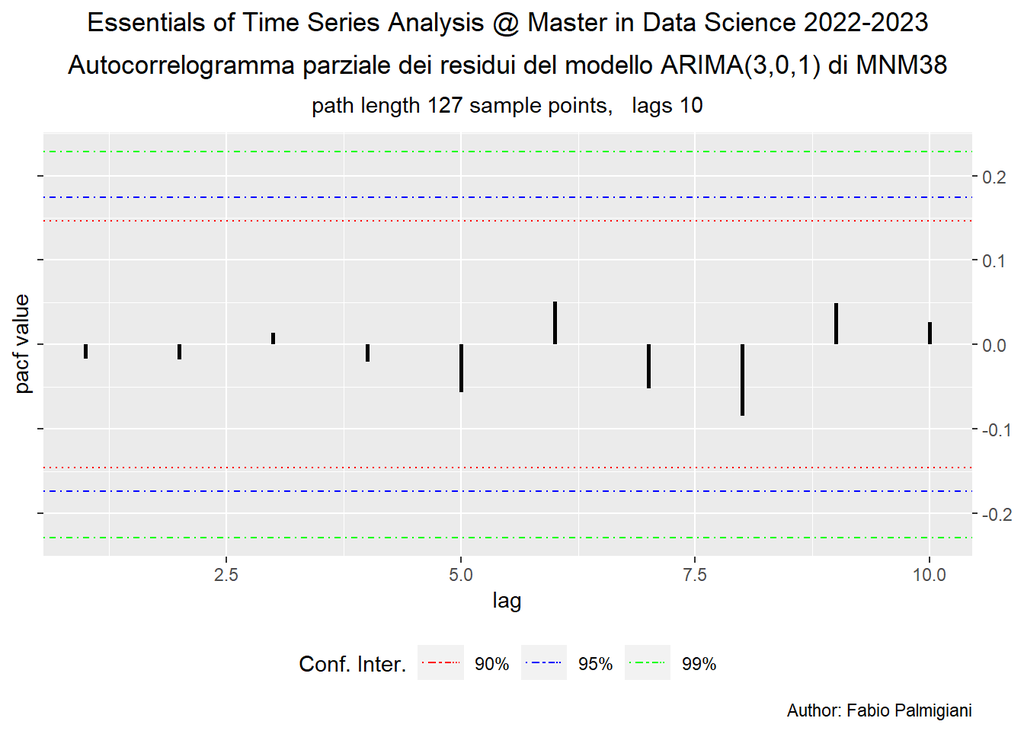

```r
# Autocottelogramma parziale
AUTOARMA_y_AIC_res_ts <- AUTOARIMA_y_AIC[["residuals"]]
AUTOARMA_y_AIC_res_vec <- as.vector(AUTOARMA_y_AIC_res_ts)
sum_pq <- length(AUTOARIMA_y_AIC[["coef"]])
y <- AUTOARMA_y_AIC_res_vec
length <- length(y)
T <- length
maxlag <- ceiling(min(10, T/4))
P_Aut_Fun_y <- pacf(y, lag.max = maxlag, plot=FALSE)
ci_90 <- qnorm((1+0.90)/2)/sqrt(length)
ci_95 <- qnorm((1+0.95)/2)/sqrt(length)
ci_99 <- qnorm((1+0.99)/2)/sqrt(length)
Plot_P_Aut_Fun_y <- data.frame(lag=P_Aut_Fun_y$lag, pacf=P_Aut_Fun_y$acf)
First_Date <- paste(Data_df$Month[1],Data_df$Year[1])
Last_Date <- paste(Data_df$Month[length],Data_df$Year[length])
title_content <- bquote(atop("Essentials of Time Series Analysis \u0040 Master in Data Science 2022-2023",
                             paste("Autocorrelogramma parziale dei residui del modello ARIMA(3,0,1) di MNM38" )))
subtitle_content <- bquote(paste("path length ", .(length), " sample points,   ", "lags ", .(maxlag)))
ggplot(Plot_P_Aut_Fun_y, aes(x=lag, y=pacf)) +
  geom_segment(aes(x=lag, y=rep(0,length(lag)), xend=lag, yend=pacf), size = 1, col="black") +
  geom_hline(aes(yintercept=-ci_90, color="CI_90"), show.legend = TRUE, lty=3) +
  geom_hline(aes(yintercept=ci_90, color="CI_90"), lty=3) +
  geom_hline(aes(yintercept=ci_95, color="CI_95"), show.legend = TRUE, lty=4) +
  geom_hline(aes(yintercept=-ci_95, color="CI_95"), lty=4) +
  geom_hline(aes(yintercept=-ci_99, color="CI_99"), show.legend = TRUE, lty=4) +
  geom_hline(aes(yintercept=ci_99, color="CI_99"), lty=4) +
  scale_x_continuous(name="lag", breaks=waiver(), label=waiver()) +
  scale_y_continuous(name="pacf value", breaks=waiver(), labels=NULL,
                     sec.axis = sec_axis(~., breaks=waiver(), labels=waiver())) +
  scale_color_manual(name="Conf. Inter.", labels=c("90%","95%","99%"),
                     values=c(CI_90="red", CI_95="blue", CI_99="green")) +
  ggtitle(title_content) +
  labs(subtitle=subtitle_content, caption=caption_content) +
  theme(plot.title=element_text(hjust = 0.5),
        plot.subtitle=element_text(hjust =  0.5),
        plot.caption = element_text(hjust = 1.0),
        legend.key.width = unit(0.8,"cm"), legend.position="bottom")
```

Test di Ljung-Box:

```r
#Ljung-Box (LB) test
y_LB <- LjungBoxTest(AUTOARMA_y_AIC_res_vec, k=1, lag.max=maxlag, StartLag=1, SquaredQ=FALSE)
show(y_LB)
```

```
##   m   Qm    pvalue
##   1 0.04 0.8509251
##   2 0.08 0.7831280
##   3 0.10 0.9501402
##   4 0.16 0.9841625
##   5 0.58 0.9653123
##   6 0.96 0.9655461
##   7 1.32 0.9703791
##   8 2.33 0.9396499
##   9 2.76 0.9484658
##  10 2.87 0.9693830
```

Dai due autocorrelogrammi c’è evidenza di non autocorrelazione dei residui del modello ARIMA(3,0,1), cosa confermata anche dal test di Ljung-Box.

Si è continuato a studiare la stazionarietà dei residui:

```r
# ADF Test
Res_DF_none <- ur.df(AUTOARMA_y_AIC_res_vec, type="none", lags=0, selectlags="Fixed")
summary(Res_DF_none)
```

```
##
## ###############################################
## # Augmented Dickey-Fuller Test Unit Root Test #
## ###############################################
##
## Test regression none
##
##
## Call:
## lm(formula = z.diff ~ z.lag.1 - 1)
##
## Residuals:
##     Min      1Q  Median      3Q     Max
## -1723.5  -738.0   -78.2   405.4  2949.5
##
## Coefficients:
##         Estimate Std. Error t value Pr(>|t|)
## z.lag.1 -1.00676    0.08834   -11.4   <2e-16 ***
## ---
## Signif. codes:  0 '***' 0.001 '**' 0.01 '*' 0.05 '.' 0.1 ' ' 1
##
## Residual standard error: 878.3 on 125 degrees of freedom
## Multiple R-squared:  0.5096, Adjusted R-squared:  0.5056
## F-statistic: 129.9 on 1 and 125 DF,  p-value: < 2.2e-16
##
##
## Value of test-statistic is: -11.3965
##
## Critical values for test statistics:
##       1pct  5pct 10pct
## tau1 -2.58 -1.95 -1.62
```

```r
# KPSS Test
Res_KPSS_mu <- ur.kpss(AUTOARMA_y_AIC_res_vec, type="mu", lags="nil", use.lag=NULL)
summary(Res_KPSS_mu)
```

```
##
## #######################
## # KPSS Unit Root Test #
## #######################
##
## Test is of type: mu with 0 lags.
##
## Value of test-statistic is: 0.1796
##
## Critical value for a significance level of:
##                 10pct  5pct 2.5pct  1pct
## critical values 0.347 0.463  0.574 0.739
```

In definitiva quindi non è stato possibile rigettare l’ipotesi che afferma che i residui del odello ARIMA(3,0,1) siano stati generati da rumori stazionari.

A questo punto bisognava capire quale distribuzione spiega meglio i residui del modello ARIMA(3,0,1). E’ stato assunto che essi siano descritti da una distribuzione Gaussiana e, per confermare questa ipotesi, sono stati eseguiti i test di Shapiro-Wilk, D’Agostino-Pearson, Anderson-Darling e Jarque Bera:

```r
# test di Shapiro-Wilk
y <- AUTOARIMA_y_AIC[["residuals"]]
y_SW <- shapiro.test(y)
show(y_SW)
```

```
##
##  Shapiro-Wilk normality test
##
## data:  y
## W = 0.97516, p-value = 0.0194
```

```r
# test di D’Agostino-Pearson
y_DP <- dagoTest(y)
show(y_DP)
```

```
##
## Title:
##  D'Agostino Normality Test
##
## Test Results:
##   STATISTIC:
##     Chi2 | Omnibus: 5.859
##     Z3  | Skewness: 2.1693
##     Z4  | Kurtosis: 1.0738
##   P VALUE:
##     Omnibus  Test: 0.05342
##     Skewness Test: 0.03006
##     Kurtosis Test: 0.2829
```

```r
# test di Anderson-Darling
y_AD <- ad.test(y)
show(y_AD)
```

```
##
##  Anderson-Darling test of goodness-of-fit
##  Null hypothesis: uniform distribution
##  Parameters assumed to be fixed
##
## data:  y
## An = Inf, p-value = 4.724e-06
```

```r
# test di Jarque Bera
y_JB <- jarque.bera.test(y)
show(y_JB)
```

```
##
##  Jarque Bera Test
##
## data:  y
## X-squared = 5.3404, df = 2, p-value = 0.06924
```

A questo punto si è diseganto l’istogramma dei residui standardizzati del modello ARIMA(3,0,1) per avere una prima evidenza visiva:

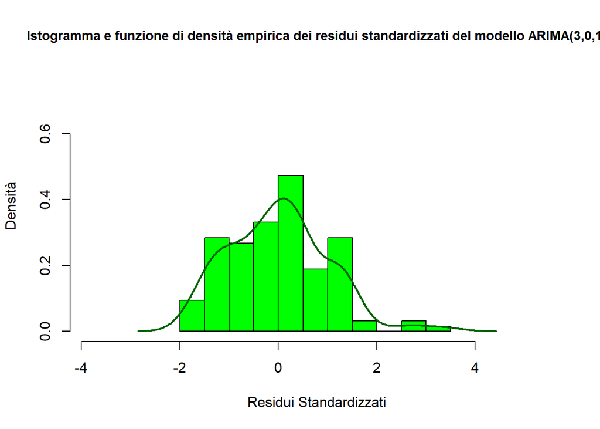

```r
z <- as.vector(AUTOARIMA_y_AIC[["residuals"]])
z_st <- (1/sd(z))*as.vector(z-mean(z)) # standardizzo i residui di ARIMA(3,0,1)
z_st_qemp <- qemp(ppoints(z_st), z_st)
z_st_demp <- demp(z_st_qemp, z_st)
z_st_pemp <- pemp(z_st_qemp, z_st)
x <- z_st_qemp
y_d <- z_st_demp
y_p <- z_st_pemp
hist(z_st, col="green", border="black", xlim=c(x[1]-2.0, x[length(x)]+2.0),
                     ylim=c(0, y_d[length(y_d)]+ 0.75),
                     freq=FALSE, main="Istogramma e funzione di densità empirica dei residui standardizzati del modello ARIMA(3,0,1)",
                     xlab="Residui Standardizzati", ylab="Densità",cex.main=0.9)
lines(density(z_st), lwd=2, col="darkgreen")
```

Si è mostrato anche la funzione di ripartizione empirica dei residui standardizzati del modello ARIMA(3,0,1):

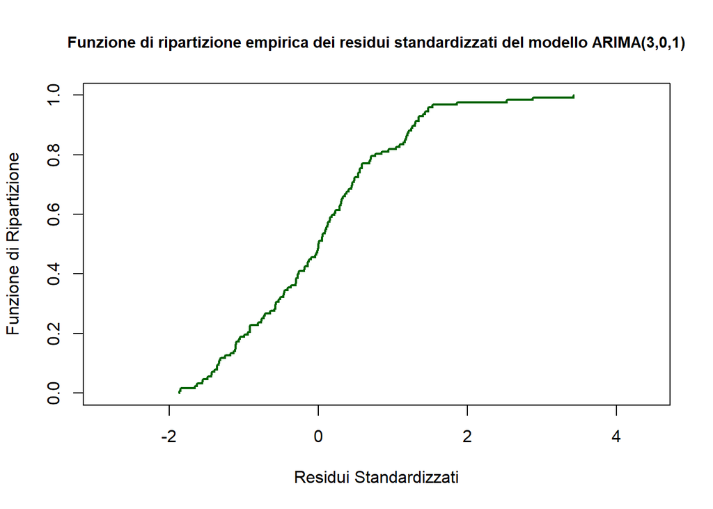

```r
ecdfPlot(z_st, discrete=TRUE, prob.method="emp.probs", type="s", plot.it=TRUE, add=FALSE, ecdf.col="darkgreen",
         ecdf.lwd=2, ecdf.lty=1, curve.fill=FALSE, main="Funzione di ripartizione empirica dei residui standardizzati del modello ARIMA(3,0,1)",
         xlab="Residui Standardizzati", ylab="Funzione di Ripartizione",
         xlim=c(x[1]-1.0, x[length(x)]+1.0),
         cex.main=0.9)
```

Dai grafici ottenuti si è indotti a pensare che la distribuzione migliore sia quella di student.

Per confermare questa tesi sono stati stimati i parametri della distribuzione teorica e si è confrontata la sua densità con quella empirica.

```r
dt_ls <- function(x, m, s, df)  1/s*dt((x-m)/s, df)
pt_ls <- function(q, m, s, df)  pt((q-m)/s, df)
qt_ls <- function(p, m, s, df)  qt(p, df)*s+m
rt_ls <- function(n, m, s, df)  rt(n,df)*s+m

# Fitto la distribuzione
fitdistr_t_ls <- fitdistr(z_st, dt_ls, start=list(m=0, s=sqrt(1/3), df=3), lower=c(0,0,2))
fitdistr_t_ls_logLik <- fitdistr_t_ls$loglik
fitdistr_t_ls_AIC <- AIC(fitdistr_t_ls, k=2)
fitdistr_t_ls_BIC <- AIC(fitdistr_t_ls, k=log(fitdistr_t_ls$n))
show(fitdistr_t_ls)
```

```
##         m             s            df
##    0.00000000    0.95773868   26.80301180
##  ( 0.09001442) ( 0.08680342) (46.83921800)
```

```r
show(fitdistr_t_ls_logLik)
```

```
## [1] -179.5025
```

```r
show(fitdistr_t_ls_AIC)
```

```
## [1] 365.005
```

```r
show(fitdistr_t_ls_BIC)
```

```
## [1] 373.5376
```

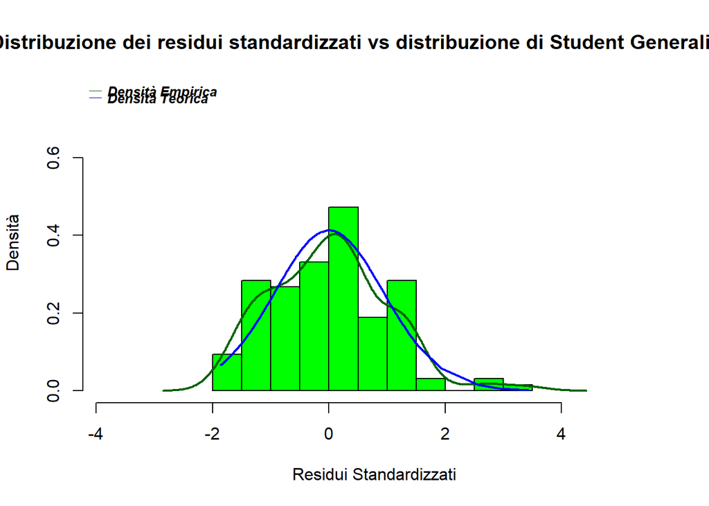

```r
m <- as.numeric(fitdistr_t_ls$estimate[1])
s <- as.numeric(fitdistr_t_ls$estimate[2])
df <- as.numeric(fitdistr_t_ls$estimate[3])

hist(z_st, col="green", border="black", xlim=c(x[1]-2.0, x[length(x)]+2.0), ylim=c(0, y_d[length(y_d)]+0.75),
     freq=FALSE, main="Distribuzione dei residui standardizzati vs distribuzione di Student Generalizzata",
     xlab="Residui Standardizzati", ylab="Densità")
lines(density(z_st), lwd=2, col="darkgreen")
lines(x, dt_ls(x, m=m, s=s, df=df), lwd=2, col="blue")
legend("topleft", legend=c("Densità Empirica", "Densità Teorica"), col=c("darkgreen", "blue"),
       lty=1, lwd=0.1, cex=0.8, x.intersp=0.50, y.intersp=0.40, text.width=2, seg.len=1, text.font=4, box.lty=0,
       inset=-0.01, bty="n")
```

Dal gragico le due densità sembrano essere molto simili, quindi sembrerebbe corretta l’ipotesi he i residui del modello ARIMA(3,0,1) siano descritti dalla distribuzione di student, per avvalorare ulteriormente l’ipotesi si sono effettuati i test di goodness of fit:

```r
KS_x_st_t_ls <- ks.test(z_st, y="pt_ls", m=m, s=s, df=df, alternative="two.sided")
show(KS_x_st_t_ls)
```

```
##
##  Asymptotic one-sample Kolmogorov-Smirnov test
##
## data:  z_st
## D = 0.053711, p-value = 0.8572
## alternative hypothesis: two-sided
```

```r
CVM_x_st_t_ls <- cvm.test(z_st, null="pt_ls", m=m, s=s, df=df, estimated=FALSE)
show(CVM_x_st_t_ls)
```

```
##
##  Cramer-von Mises test of goodness-of-fit
##  Null hypothesis: distribution 'pt_ls'
##  with parameters m = 0, s = 0.957738681217872, df = 26.8030118029794
##  Parameters assumed to be fixed
##
## data:  z_st
## omega2 = 0.056729, p-value = 0.8355
```

```r
AD_x_st_t_ls <- ad.test(z_st,"pt_ls", m=m, s=s, df=df, estimated=FALSE)
show(AD_x_st_t_ls)
```

```
##
##  Anderson-Darling test of goodness-of-fit
##  Null hypothesis: distribution 'pt_ls'
##  with parameters m = 0, s = 0.957738681217872, df = 26.8030118029794
##  Parameters assumed to be fixed
##
## data:  z_st
## An = 0.52114, p-value = 0.725
```

Infine, come ulteriore conferma, si è disegnato il plot nel quale si vede come i quantili empirici sono concordi con i quantili teorici della distribuzione di Student.

```r
x <- z_st_qemp
car::qqPlot(x, distribution ="t_ls", m=m, s=s, df=df,
            line="robust",
            envelope=list(level=0.95, alpha=0.15, border=TRUE), col=carPalette()[2], col.lines=carPalette()[8],
            pch=16, cex=0.5, las=1,
            main=bquote(atop("Q-Q plot dei residui standardizzati del modello ARIMA(3,0,1)",
                             paste("Contro distribuzione di Student Gen. con m = ", .(m),", s = ", .(round(s, 3)),", e df = ", .(round(df,3)),"."))),
            xlab=bquote(paste("Quantili teorici distribuzione di Student Generalizzata")),
            ylab="Quantili empirici distribuzione dei residui")
```

```
## [1] 127 126
```

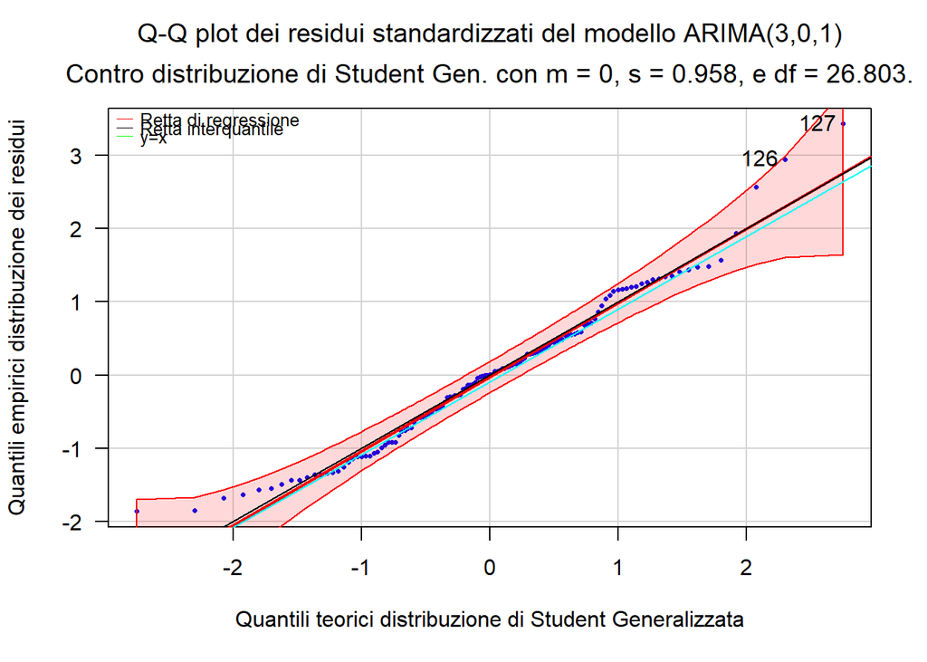

```r
# aggiunta della linea interquantile
probs <- c(0.25,0.75)
quart_x <- as.vector(quantile(x, probs))
quart_t <- qt_ls(probs, m=m, s=s, df=df)
slope <- diff(quart_x)/diff(quart_t)
intercept <- quart_x[1]-slope*quart_t[1]
abline(a=intercept, b=slope, col="cyan", lwd=1)

abline(a=0, b=1, col="black", lwd=1)
legend("topleft",
       legend=c("Retta di regressione", "Retta interquantile", "y=x"),
       col=c("red", "black", "green"), lty=1, lwd=0.1, cex=0.80, x.intersp=0.50,
       y.intersp=0.40, text.width=2, seg.len=1, inset=-0.01, bty="n")
```

## Predizione

```r
Test_end <- nrow(MNM38_df)
Test_start <- TS_length+1

MNM38_test_df <- MNM38_df[Test_start:Test_end,]
```

Si è processo con la predizione del trend e della stagionalità:

```r
# PREDIZIONE TREND
t <- 1:TS_length
y <- MNM38_dec_df$y_trend

trend_lm <- lm(y_trend~t, data=MNM38_dec_df)
trend_pred = predict(trend_lm, MNM38_test_df)

# PREDIZIONE STAGIONALITA'
y_seas <- ts(MNM38_dec_df$y_seas,start=c(1977, 12), frequency=12 )
y_seas_naive_pred <- c(y_seas[(length(y_seas)-11):length(y_seas)],y_seas[(length(y_seas)-11):(length(y_seas)-2)])
y_seas_naive_for <- c(y_seas, y_seas_naive_pred)
```

Si è effettuata una previsione dei residui del modello STL utilizzando il modello ARIMA(3,0,1). Per prima cosa sono stati recuperati i dati del training set, che serviranno per effettuare le previsione dei residui e successivamente per creare il grafico con la previsione.

```r
y_rem <- as.vector(AUTOARIMA_y_AIC[["x"]])
train_trend = MNM38_dec_df$y_trend
train_seas = MNM38_dec_df$y_seas
train_res = MNM38_dec_df$res
training_data = train_trend+train_seas+train_res

AUTOARIMA_y_AIC[["coef"]]
```

```
##        ar1        ar2        ar3        ma1
##  0.7246954  0.2351288 -0.2749196 -0.8328558
```

```r
phi_1 = AUTOARIMA_y_AIC[["coef"]][["ar1"]]
phi_2 = AUTOARIMA_y_AIC[["coef"]][["ar2"]]
phi_3 = AUTOARIMA_y_AIC[["coef"]][["ar3"]]
sigma2 = AUTOARIMA_y_AIC[["sigma2"]]
sigma_w <- sqrt(sigma2)

n <- 100000
y_pred_stud_mat <- matrix(NA, nrow=TsS_length, ncol=n)
for(k in 1 :n){
  set.seed(k)
  w <- rt_ls(TsS_length, m=m, s=s, df=df)
  y_pred_stud_mat[1,k] <- phi_1*y_rem[TS_length] + phi_2*y_rem[(TS_length-1)] + phi_3*y_rem[(TS_length-2)] + sigma_w*w[1]
  y_pred_stud_mat[2,k] <- phi_1*y_pred_stud_mat[1,k] + phi_2*y_rem[TS_length] + phi_3*y_rem[(TS_length-1)] + sigma_w*w[2]
  y_pred_stud_mat[3,k] <- phi_1*y_pred_stud_mat[2,k] + phi_2*y_pred_stud_mat[1] + phi_3*y_rem[TS_length] + sigma_w*w[3]
  for(t in 4:TsS_length){
    y_pred_stud_mat[t,k] <- phi_1*y_pred_stud_mat[(t-1),k] + phi_2*y_pred_stud_mat[(t-2),k] + phi_3*y_pred_stud_mat[(t-3),k] + sigma_w*w[t]
  }
}
```

```r
y_pred_stud_mat_mean <- rowMeans(y_pred_stud_mat)
y_pred_norm_mat_090_low_int <- rowQuantileC(y_pred_stud_mat, 0.10)
y_pred_norm_mat_090_upp_int <- rowQuantileC(y_pred_stud_mat, 0.90)
y_pred_norm_mat_095_low_int <- rowQuantileC(y_pred_stud_mat, 0.05)
y_pred_norm_mat_095_upp_int <- rowQuantileC(y_pred_stud_mat, 0.95)

MNM38_train_df_vec <-as.vector(MNM38_train_df$Values)

prediction <- trend_pred + y_seas_naive_pred + y_pred_stud_mat_mean
MNM38_point_pred <- prediction
MNM38_point_pred_int <- c(MNM38_train_df$Values, MNM38_point_pred)
MNM38_boot_090_low_naive_pred_int <- (MNM38_point_pred + y_pred_norm_mat_090_low_int)
MNM38_boot_090_upp_naive_pred_int <- (MNM38_point_pred + y_pred_norm_mat_090_upp_int)
MNM38_boot_095_low_naive_pred_int <- (MNM38_point_pred + y_pred_norm_mat_095_low_int)
MNM38_boot_095_upp_naive_pred_int <- (MNM38_point_pred + y_pred_norm_mat_095_upp_int)

MNM38_boot_090_low_naive_for_int <- c(rep(NA,TS_length),MNM38_boot_090_low_naive_pred_int)
MNM38_boot_090_upp_naive_for_int <- c(rep(NA,TS_length),MNM38_boot_090_upp_naive_pred_int)
MNM38_boot_095_low_naive_for_int <- c(rep(NA,TS_length),MNM38_boot_095_low_naive_pred_int)
MNM38_boot_095_upp_naive_for_int <- c(rep(NA,TS_length),MNM38_boot_095_upp_naive_pred_int)


MNM38_pred_full_df <- data.frame(Year = trunc(time(MNM38_ts)), Month=month.abb[cycle(MNM38_ts)])
MNM38_pred_full_df <- add_column(MNM38_pred_full_df, t=c(1:nrow(MNM38_pred_full_df)), .before="Year")

MNM38_pred_full_df <- add_column(MNM38_pred_full_df,
                                 MNM38_Value=MNM38_df$Values,
                                 MNM38_point_for=MNM38_point_pred_int,
                                 MNM38_090_low_for_int=MNM38_boot_090_low_naive_for_int,
                                 MNM38_090_upp_for_int=MNM38_boot_090_upp_naive_for_int,
                                 MNM38_095_low_for_int=MNM38_boot_095_low_naive_for_int,
                                 MNM38_095_upp_for_int=MNM38_boot_095_upp_naive_for_int)
```

Si è concluso quindi lo studio della serie, disegnando il grafico finale che mostra la previsione puntuale e le bande di confidenza:

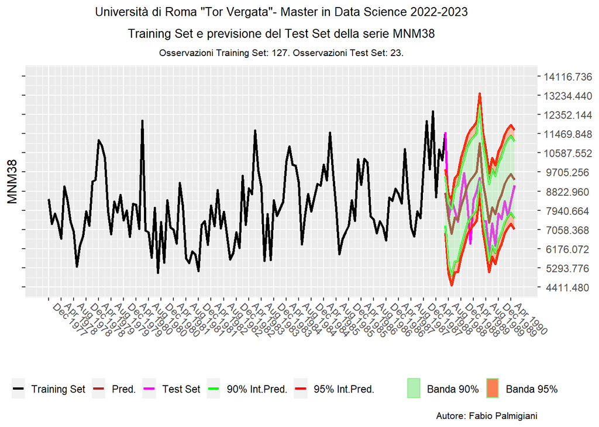

```r
Data_df <- MNM38_pred_full_df
length <- nrow(Data_df)
T<- TS_length
First_Date <- paste(Data_df$Month[1],Data_df$Year[1])
Last_Date <- paste(Data_df$Month[length],Data_df$Year[length])
title_content <- bquote(atop("Università di Roma \"Tor Vergata\"- Master in Data Science 2022-2023",
                             paste("Training Set e previsione del Test Set della serie MNM38")))
subtitle_content <- bquote(paste("Osservazioni Training Set: ", .(TS_length),". Osservazioni Test Set: ", .(TsS_length),"."))
caption_content <-"Autore: Fabio Palmigiani"
x_name <- bquote("")
x_breaks_num <-33
x_breaks_low <- Data_df$t[1]
x_breaks_up <- Data_df$t[length]
x_binwidth <- floor((x_breaks_up-x_breaks_low)/x_breaks_num)
x_breaks <- seq(from=x_breaks_low, to=x_breaks_up, by=x_binwidth)
if((max(x_breaks)-x_breaks_up)>x_binwidth/2){x_breaks <- c(x_breaks,x_breaks_up)}
x_labs <- paste(Data_df$Month[x_breaks],Data_df$Year[x_breaks])
J <-0
x_lims <- c(x_breaks_low-J*x_binwidth, x_breaks_up+J*x_binwidth)
y_name <- bquote("MNM38")
y_breaks_num <-10
y_max <- max(na.omit(Data_df$MNM38_Value),na.omit(Data_df$MNM38_095_upp_for_int))
y_min <- min(na.omit(Data_df$MNM38_Value),na.omit(Data_df$MNM38_095_low_for_int))
y_binwidth <- round((y_max-y_min)/y_breaks_num, digits=3)
y_breaks_low <- floor(y_min/y_binwidth)*y_binwidth
y_breaks_up <- ceiling(y_max/y_binwidth)*y_binwidth
y_breaks <- round(seq(from=y_breaks_low, to=y_breaks_up, by=y_binwidth),digits=3)
y_labs <- format(y_breaks, scientific=FALSE)
K <-0
y_lims <- c((y_breaks_low-K*y_binwidth), (y_breaks_up+K*y_binwidth))
line_black <- bquote("Training Set")
line_magenta <- bquote("Test Set")
line_brown <- bquote("Pred.")
line_green <- bquote("90% Int.Pred.")
line_red <- bquote("95% Int.Pred.")
leg_line_labs <- c(line_black, line_brown, line_magenta, line_green, line_red)
leg_line_breaks <- c("line_black","line_brown","line_magenta","line_green","line_red")
leg_line_cols <- c("line_black"="black","line_brown"="brown","line_magenta"="magenta","line_green"="green","line_red"="red")
fill_g <- bquote("Banda 90%")
fill_r <- bquote("Banda 95%")
leg_fill_labs <- c( fill_g, fill_r)
leg_fill_breaks <- c("fill_g","fill_r")
leg_fill_cols <- c("fill_g"="lightgreen","fill_r"="orangered")
leg_col_labs <- leg_line_labs
leg_col_breaks <- leg_line_breaks
leg_col_cols <- leg_line_cols
y_pred_lp <- ggplot(Data_df, aes(x=t)) +
  geom_line(data=subset(Data_df, Data_df$t <= t[T+1]), aes(y=MNM38_Value, color="line_black"), linetype="solid", alpha=1, size=1, group=1) +
  geom_line(data=subset(Data_df, Data_df$t >= t[T+1]), aes(y=MNM38_Value, color="line_magenta"), linetype="solid", alpha=1, size=1, group=1) +
  geom_line(data=subset(Data_df, Data_df$t >= t[T+1]), aes(y=MNM38_point_for, colour="line_brown"), linetype="solid", alpha=1, size=1) +
  geom_line(data=subset(Data_df, Data_df$t >= t[T+1]), aes(y=MNM38_095_low_for_int, colour="line_red"), linetype="solid", alpha=1, size=1) +
  geom_line(data=subset(Data_df, Data_df$t >= t[T+1]), aes(y=MNM38_095_upp_for_int, colour="line_red"), linetype="solid", alpha=1, size=1) +
  geom_line(data=subset(Data_df, Data_df$t >= t[T+1]), aes(y=MNM38_090_low_for_int, colour="line_green"), linetype="solid", alpha=1, size=1) +
  geom_line(data=subset(Data_df, Data_df$t >= t[T+1]), aes(y=MNM38_090_upp_for_int, colour="line_green"), linetype="solid", alpha=1, size=1) +
  geom_ribbon(data=subset(Data_df, Data_df$t >= t[T+1]),
              alpha=0.3, colour="orangered", aes(ymin=MNM38_095_low_for_int, ymax=MNM38_090_low_for_int, fill="fill_r")) +
  geom_ribbon(data=subset(Data_df, Data_df$t >= t[T+1]),
              alpha=0.3, colour="orangered", aes(ymin=MNM38_090_upp_for_int, ymax=MNM38_095_upp_for_int, fill="fill_r")) +
  geom_ribbon(data=subset(Data_df, Data_df$t >= t[T+1]),
              alpha=0.3, colour="lightgreen", aes(ymin=MNM38_090_low_for_int, ymax=MNM38_090_upp_for_int, fill="fill_g")) +
  scale_x_continuous(name=x_name, breaks=x_breaks, labels=x_labs, limits=x_lims) +
  scale_y_continuous(name=y_name, breaks=y_breaks, labels=NULL, limits=y_lims, sec.axis= sec_axis(~., breaks=y_breaks, labels=y_labs)) +
  ggtitle(title_content) + labs(subtitle=subtitle_content, caption=caption_content) +
  guides(linetype="none", shape="none") + scale_colour_manual(name="", labels=leg_line_labs, values=leg_line_cols, breaks=leg_line_breaks) +
  scale_fill_manual(name="", labels=leg_fill_labs, values=leg_fill_cols, breaks=leg_fill_breaks) +
  guides(colour=guide_legend(order=1), fill=guide_legend(order=2)) + theme(plot.title=element_text(hjust =0.5, size =10),
  plot.subtitle=element_text(hjust =0.5, size =8),
  plot.caption = element_text(hjust =1.0, size =8),
  axis.text.x = element_text(angle=-45, vjust=1, hjust=-0.3),
  legend.key.width = unit(0.4,"cm"), legend.position="bottom")
plot(y_pred_lp)
```

# Conclusione